# GSEM factor analysis - sensitivity analyses

20 December, 2024

```r
library(data.table)
library(tidyverse)
library(GenomicSEM)
library(psych)
library(lavaan)
library(Matrix)
library(semptools)
library(semPlot)
library(svglite)
library(simstandard)
library(knitr)
```

# Genomic SEM factor analysis: sensitivity follow-up analyses

We take the model that showed the best fit and carry it forward to do sensitivity and robustness analyses. We used the EFA-based 4-factor model, the bifactor per substance, and bifactor per trait type.

# Odd versus even chromosomes

### 13. EFA 4 factor - Even/ odd chromosomes

We used the whole genome to fit both EFA and CFA models for practical and theoretical reasons. If it is true that for many traits the genetic signal is rather localized (rather than spread out evenly across the genome) this would give a different factor structure in different chromosome subsets. To check this, we compare the factor structure for even and odd chromosomes separately. Indeed, the factor structure is quite different.

EFA for even:

```r
load('data/mldsc_29May2023.14.EVEN.RData')

Ssmooth <- as.matrix((nearPD(ldscOut$S, corr = FALSE))$mat)

EFA <-factanal(covmat = Ssmooth, factors = 4, rotation = 'promax')
```

```r
print(EFA$loadings, digits = 2, cutoff = .3, sort = TRUE)
```

```
##
## Loadings:
##         Factor1 Factor2 Factor3 Factor4
## SMKCES   0.91
## PACKYE   1.10
## SMKDEP   0.73
## ALCDEP   0.62            0.43
## SMKINI   0.31    0.53
## CANEV            1.04
## CANFL            1.00
## ALCCON                   0.99
## ALCFRQ  -0.59            0.78
## ALCP                     0.75
## CANDEP                           0.59
## OPIODEP                          1.18
## SMKAGE  -0.33                   -0.43
## COCDEP   0.46                    0.32
##
##                Factor1 Factor2 Factor3 Factor4
## SS loadings       3.89    2.58    2.37    2.26
## Proportion Var    0.28    0.18    0.17    0.16
## Cumulative Var    0.28    0.46    0.63    0.79
```

EFA for odd:

```r
load('data/mldsc_29May2023.14.ODD.RData')

Ssmooth <- as.matrix((nearPD(ldscOut$S, corr = FALSE))$mat)

EFA <-factanal(covmat = Ssmooth, factors = 4, rotation = 'promax')
```

```r
print(EFA$loadings, digits = 2, cutoff = .3, sort = TRUE)
```

```
##
## Loadings:
##         Factor1 Factor2 Factor3 Factor4
## SMKINI   0.90    0.43   -0.38
## SMKCES   0.66   -0.35
## PACKYE   0.61
## SMKAGE  -0.86
## CANEV            0.96
## CANFL            0.66
## COCDEP                   0.94
## OPIODEP          0.54    0.62
## ALCCON                           0.74
## ALCFRQ  -0.35                    0.52
## ALCP                             0.58
## ALCDEP   0.38            0.44    0.54
## SMKDEP   0.49
## CANDEP   0.32    0.48    0.32
##
##                Factor1 Factor2 Factor3 Factor4
## SS loadings       3.02    2.31    1.88    1.68
## Proportion Var    0.22    0.16    0.13    0.12
## Cumulative Var    0.22    0.38    0.51    0.63
```

### 12. EFA 4 factor - Varimax rotated

EFA:

```r
load('data/mldsc_29May2023.14.TOT.RData')

Ssmooth <- as.matrix((nearPD(ldscOut$S, corr = FALSE))$mat)

EFA <-factanal(covmat = Ssmooth, factors = 4, rotation = 'varimax')
```

```r
print(EFA$loadings, digits = 2, cutoff = .3, sort = TRUE)
```

```
##
## Loadings:
##         Factor1 Factor2 Factor3 Factor4
## SMKCES   0.76
## PACKYE   0.87
## SMKDEP   0.69
## ALCDEP   0.59            0.49
## SMKAGE  -0.46   -0.51
## CANDEP           0.66            0.42
## COCDEP   0.51    0.67
## OPIODEP          0.93
## ALCCON                   0.85
## ALCFRQ  -0.45            0.75
## ALCP                     0.80
## CANEV            0.30            0.81
## CANFL                            0.97
## SMKINI   0.40    0.37            0.43
##
##                Factor1 Factor2 Factor3 Factor4
## SS loadings       3.27    2.58    2.39    2.20
## Proportion Var    0.23    0.18    0.17    0.16
## Cumulative Var    0.23    0.42    0.59    0.75
```

CFA:

```r
load('data/mldsc_29May2023.14.TOT.RData')

CFA <- '
F1 =~ NA*SMKCES + PACKYE + SMKDEP + ALCDEP + SMKAGE + COCDEP + ALCFRQ + SMKINI
F2 =~ NA*SMKAGE + CANDEP + COCDEP + OPIODEP + CANEV + SMKINI
F3 =~ NA*ALCDEP + ALCCON + ALCFRQ + ALCP
F4 =~ NA*CANDEP + CANEV + CANFL + SMKINI

F1~~1*F1
F2~~1*F2
F3~~1*F3
F4~~1*F4

F1~~0*F2
F1~~0*F3
F1~~0*F4
F2~~0*F3
F2~~0*F4
F3~~0*F4

a > .001
ALCDEP ~~ a*ALCDEP

b > .001
CANFL ~~ b*CANFL

c > .001
OPIODEP ~~ c*OPIODEP
'

#run the model
fit <- usermodel(ldscOut, estimation = "DWLS", model = CFA, CFIcalc = TRUE)
```

```r
fitlabel <- paste0("CFI = ", round(fit$modelfit$CFI,3), ", SRMR = ", round(fit$modelfit$SRMR,3), ", AIC = ", round(fit$modelfit$AIC), ", Chisq = ", round(fit$modelfit$chisq))
kable(fitlabel)
```

| x |
| --- |
| CFI = 0.795, SRMR = 0.223, AIC = 2998, Chisq = 2926 |

**Click to expand table with model parameters**

```r
kable(fit$results)
```

|  | lhs | op | rhs | Unstand_Est | Unstand_SE | STD_Genotype | STD_Genotype_SE | STD_All | p_value |
| --- | --- | --- | --- | --- | --- | --- | --- | --- | --- |
| 18 | F1 | =~ | SMKCES | 0.1966878 | 0.00831600041774931 | 0.7319164 | 0.0309466298259979 | 0.7319164 | 0.0000000 |
| 16 | F1 | =~ | PACKYE | 0.2807103 | 0.0116482316097303 | 0.9302382 | 0.0386010743785031 | 0.9302383 | 0.0000000 |
| 19 | F1 | =~ | SMKDEP | 0.2786676 | 0.0190963383830954 | 0.7917669 | 0.0542584804845957 | 0.7917680 | 0.0000000 |
| 13 | F1 | =~ | ALCDEP | 0.3261854 | 0.0206003445714664 | 0.8577766 | 0.0541416963777319 | 0.7927426 | 0.0000000 |
| 17 | F1 | =~ | SMKAGE | -0.1192055 | 0.00701583666280733 | -0.5450965 | 0.0320800836964788 | -0.5450966 | 0.0000000 |
| 15 | F1 | =~ | COCDEP | 0.3329328 | 0.0323476876143071 | 0.6102959 | 0.0592953975187535 | 0.6102941 | 0.0000000 |
| 14 | F1 | =~ | ALCFRQ | -0.0783113 | 0.00676578239106861 | -0.2721990 | 0.0235147929223214 | -0.2721991 | 0.0000000 |
| 20 | F1 | =~ | SMKINI | 0.1682224 | 0.00754054650341189 | 0.4878165 | 0.0218647944460638 | 0.4878166 | 0.0000000 |
| 28 | F2 | =~ | SMKAGE | 0.1386649 | 0.00957664754416511 | 0.6337423 | 0.0437743570789044 | 0.6337425 | 0.0000000 |
| 24 | F2 | =~ | CANDEP | -0.2311230 | 0.030675533349946 | -0.7718939 | 0.102412151297334 | -0.7718603 | 0.0000000 |
| 26 | F2 | =~ | COCDEP | -0.2176852 | 0.0357063923150459 | -0.3990094 | 0.06544605080254 | -0.3990083 | 0.0000000 |
| 27 | F2 | =~ | OPIODEP | -0.4681836 | 0.0518883185999369 | -1.0479790 | 0.116109113826728 | -1.0479790 | 0.0000000 |
| 25 | F2 | =~ | CANEV | -0.1863452 | 0.0283410434003309 | -0.3251797 | 0.0493947013407848 | -0.3251801 | 0.0000000 |
| 29 | F2 | =~ | SMKINI | -0.2006176 | 0.0125288589318484 | -0.5819752 | 0.0363424832936799 | -0.5819753 | 0.0000000 |
| 33 | F3 | =~ | ALCDEP | 0.2504646 | 0.0235809969775064 | 0.6588042 | 0.0619763346875808 | 0.6088557 | 0.0000000 |
| 32 | F3 | =~ | ALCCON | 0.2506357 | 0.00919004980623609 | 0.9530255 | 0.0349445404718969 | 0.9530256 | 0.0000000 |
| 34 | F3 | =~ | ALCFRQ | 0.1621737 | 0.00744545412462953 | 0.5636443 | 0.0258761972993057 | 0.5636443 | 0.0000000 |
| 35 | F3 | =~ | ALCP | 0.2035642 | 0.0100368993388664 | 0.8463106 | 0.0417261715665887 | 0.8463105 | 0.0000000 |
| 37 | F4 | =~ | CANDEP | 0.0657730 | 0.0354439449537792 | 0.2194917 | 0.118394215488937 | 0.2194821 | 0.0634976 |
| 38 | F4 | =~ | CANEV | 0.4408740 | 0.0359594935701795 | 0.7672618 | 0.0625669446044601 | 0.7672628 | 0.0000000 |
| 39 | F4 | =~ | CANFL | 0.2324011 | 0.0251872505294009 | 1.0995848 | 0.118988963399531 | 1.0995848 | 0.0000000 |
| 40 | F4 | =~ | SMKINI | 0.1655908 | 0.0130501231849498 | 0.4798283 | 0.0378022073575309 | 0.4798284 | 0.0000000 |
| 2 | ALCDEP | ~~ | ALCDEP | 0.0009999 | 0.0297121834237314 | 0.0009999 | 0.205286823913693 | 0.0009999 | 0.9731527 |
| 7 | CANFL | ~~ | CANFL | 0.0009994 | 0.0175509693079741 | 0.0010000 | 0.391190761515963 | 0.0008264 | 0.9545901 |
| 41 | OPIODEP | ~~ | OPIODEP | 0.0010000 | 0.0753093432601302 | 0.0010000 | 0.377163649537648 | 0.0009097 | 0.9894058 |
| 46 | SMKINI | ~~ | SMKINI | 0.0229535 | 0.0053919804652675 | 0.1931045 | 0.0452827180134078 | 0.1931045 | 0.0000207 |
| 44 | SMKCES | ~~ | SMKCES | 0.0335201 | 0.00349214821288201 | 0.4642983 | 0.0483614015255456 | 0.4642984 | 0.0000000 |
| 42 | PACKYE | ~~ | PACKYE | 0.0122453 | 0.00616685201072851 | 0.1346566 | 0.0677279635442738 | 0.1346566 | 0.0470698 |
| 43 | SMKAGE | ~~ | SMKAGE | 0.0143903 | 0.00287471322053171 | 0.3012401 | 0.0600736623236714 | 0.3012402 | 0.0000006 |
| 45 | SMKDEP | ~~ | SMKDEP | 0.0462074 | 0.0166187683411114 | 0.3731025 | 0.134169980173202 | 0.3731035 | 0.0054286 |
| 1 | ALCCON | ~~ | ALCCON | 0.0063309 | 0.00350305746006547 | 0.0917422 | 0.0506448177989612 | 0.0917422 | 0.0707253 |
| 3 | ALCFRQ | ~~ | ALCFRQ | 0.0503526 | 0.00242302001029847 | 0.6082127 | 0.0292690209105365 | 0.6082128 | 0.0000000 |
| 4 | ALCP | ~~ | ALCP | 0.0164160 | 0.00412742642339659 | 0.2837587 | 0.0713401450893022 | 0.2837586 | 0.0000697 |
| 6 | CANEV | ~~ | CANEV | 0.1003515 | 0.0281263578480348 | 0.3055650 | 0.0851333333571209 | 0.3055657 | 0.0003599 |
| 5 | CANDEP | ~~ | CANDEP | 0.0319213 | 0.0297100767660756 | 0.3560902 | 0.331334047888876 | 0.3560592 | 0.2826319 |
| 8 | COCDEP | ~~ | COCDEP | 0.1393780 | 0.0511336807580098 | 0.4683362 | 0.171811984236149 | 0.4683335 | 0.0064154 |
| 9 | F1 | ~~ | F1 | 1.0000000 |  | 1.0000000 |  | 1.0000000 | NA |
| 21 | F2 | ~~ | F2 | 1.0000000 |  | 1.0000000 |  | 1.0000000 | NA |
| 30 | F3 | ~~ | F3 | 1.0000000 |  | 1.0000000 |  | 1.0000000 | NA |
| 36 | F4 | ~~ | F4 | 1.0000000 |  | 1.0000000 |  | 1.0000000 | NA |
| 10 | F1 | ~~ | F2 | 0.0000000 |  | 0.0000000 |  | 0.0000000 | NA |
| 11 | F1 | ~~ | F3 | 0.0000000 |  | 0.0000000 |  | 0.0000000 | NA |
| 12 | F1 | ~~ | F4 | 0.0000000 |  | 0.0000000 |  | 0.0000000 | NA |
| 22 | F2 | ~~ | F3 | 0.0000000 |  | 0.0000000 |  | 0.0000000 | NA |
| 23 | F2 | ~~ | F4 | 0.0000000 |  | 0.0000000 |  | 0.0000000 | NA |
| 31 | F3 | ~~ | F4 | 0.0000000 |  | 0.0000000 |  | 0.0000000 | NA |

```r
fwrite(fit$results, "results/modeloutput/EFA4factor_varimax.csv")
```

#### Plot EFA 4 factor - Varimax rotated

```r
semPlotModel_GSEM=function(gsem.object=GWISoutput , est.label="STD_All"){

       object=gsem.object$results
       object$free=0
       numb=1:length(which(object$op!="~~"))
       object$free[which(object$op!="~~")]=numb
       varNames <- lavaanNames(object, type = "ov")
       factNames <- lavaanNames(object, type = "lv")
       factNames <- factNames[!factNames %in% varNames]
       n <- length(varNames)
       k <- length(factNames)
       if (is.null(object$label))
         object$label <- rep("", nrow(object))
       semModel <- new("semPlotModel")
       object$est <- object[,est.label]
       object$se <- object[,"STD_Genotype_SE"]

       if (is.null(object$group))
         object$group <- ""
       semModel@Pars <- data.frame(label = object$label, lhs = ifelse(object$op ==
                                                                        "~" | object$op == "~1", object$rhs, object$lhs), edge = "--",
                                   rhs = ifelse(object$op == "~" | object$op == "~1", object$lhs,
                                                object$rhs), est = object$est, std = NA, group = object$group,
                                   fixed = object$free==0, par = object$free, stringsAsFactors = FALSE)
       semModel@Pars$edge[object$op == "~~"] <- "<->"
       semModel@Pars$edge[object$op == "~*~"] <- "<->"
       semModel@Pars$edge[object$op == "~"] <- "~>"
       semModel@Pars$edge[object$op == "=~"] <- "->"
       semModel@Pars$edge[object$op == "~1"] <- "int"
       semModel@Pars$edge[grepl("\\|", object$op)] <- "|"
       semModel@Thresholds <- semModel@Pars[grepl("\\|", semModel@Pars$edge),
                                            -(3:4)]
       semModel@Pars <- semModel@Pars[!object$op %in% c(":=", "<",
                                                        ">", "==", "|", "<", ">"), ]
       semModel@Vars <- data.frame(name = c(varNames, factNames),
                                   manifest = c(varNames, factNames) %in% varNames, exogenous = NA,
                                   stringsAsFactors = FALSE)
       semModel@ObsCovs <- list()
       semModel@ImpCovs <- list()
       semModel@Computed <- FALSE
       semModel@Original <- list(object)
       return(semModel)

}

nodelab <- c("SmkCes", "PackYea", "SmkDep", "SmkAge",
              "CocDep", "AlcDep","AlcFrq","OpioDep","SmkIni",
              "CanDep","CanIni",
              "AlcCon",  "AlcPro",
              "CanFrq",

              "F1", "F2", "F3", "F4")

edge.col <- c(rep("#bebada",8),
              rep("#fb8072",6),
              rep("#bc80bd",4),
              rep("#fdb462",4),
              rep("black", 3),
              rep("grey", 18),
              rep("white",3))


svg("results/semplot_4F_varimax.svg", width = 8, height = 8)

semPaths(semPlotModel_GSEM(fit),
         layout="tree",
         curve = 2.5,
         whatLabels = "est",
         residuals = T,
         nodeLabels = nodelab,
         edge.color = edge.col,
         color = list(lat = c("#bebada", "#fb8072", "#fdb462", "#bc80bd"),
              man = "#f2f2f2"),
         rotation = 2
         ,edge.label.position = c(rep(0.8, 8), rep(0.3, 6), rep(0.4, 4), rep(0.3, 4), rep(0.5, 30))
         )

dev.off()
```

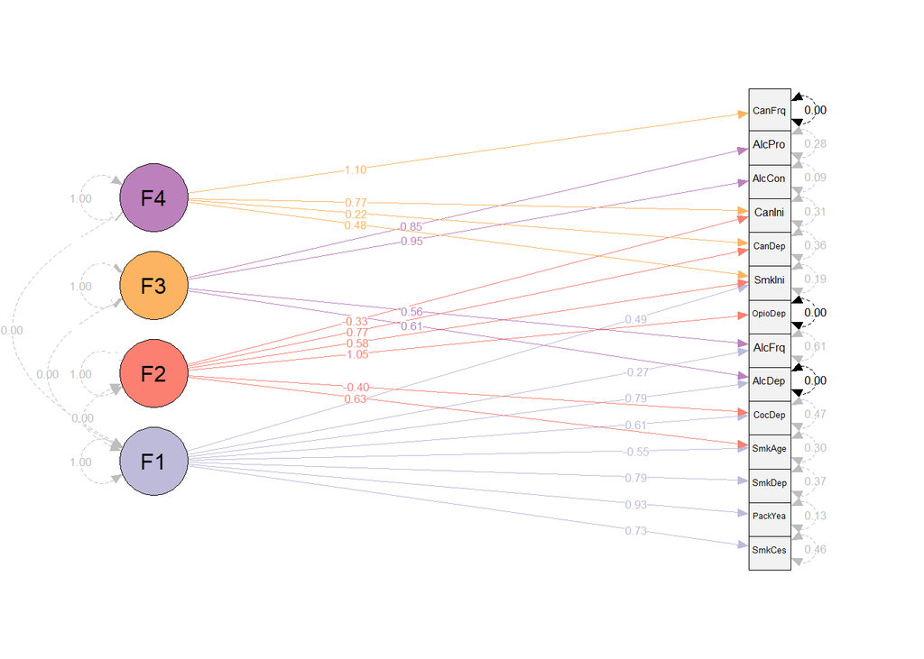

```r
semPaths(semPlotModel_GSEM(fit),
         layout="tree",
         curve = 2.5,
         whatLabels = "est",
         residuals = T,
         nodeLabels = nodelab,
         edge.color = edge.col,
         color = list(lat = c("#bebada", "#fb8072", "#fdb462", "#bc80bd"),
              man = "#f2f2f2"),
         rotation = 2
         ,edge.label.position = c(rep(0.8, 8), rep(0.3, 6), rep(0.4, 4), rep(0.3, 4), rep(0.5, 30))
         )
```

# Index-event bias adjusted

### 11. EFA 4 factor - Index-event adjusted

We explore if the Hunter-slope adjusted summary statistics show a different clustering than the unadjusted ones, again extracting 4 factors. The factor structure is somewhat different, but the fit is still decent. Of all models, I think this is the only one where smoking age has a positive loading on a factor (same direction as other indicators).

```r
load('data/mldsc_29May2023.hunted.age.14.TOT.RData')

Ssmooth <- as.matrix((nearPD(ldscOut$S, corr = FALSE))$mat)

EFA <-factanal(covmat = Ssmooth, factors = 4, rotation = 'promax')
```

```r
print(EFA, digits = 2, cutoff = .3, sort = TRUE)
```

```
##
## Call:
## factanal(factors = 4, covmat = Ssmooth, rotation = "promax")
##
## Uniquenesses:
##  SMKINI  SMKCES  PACKYE  SMKAGE  SMKDEP  ALCCON  ALCFRQ    ALCP  ALCDEP   CANEV
##    0.42    0.48    0.45    0.83    0.65    0.10    0.16    0.28    0.18    0.00
##  CANDEP   CANFL  COCDEP OPIODEP
##    0.33    0.29    0.23    0.00
##
## Loadings:
##         Factor1 Factor2 Factor3 Factor4
## SMKCES   0.78
## PACKYE   0.79
## SMKDEP   0.52
## ALCDEP   0.71    0.38
## ALCCON           0.90
## ALCFRQ  -0.62    0.90
## ALCP             0.74
## CANEV                    0.98
## CANFL                    0.89
## CANDEP                           0.72
## OPIODEP                          0.98
## SMKINI   0.36            0.49
## SMKAGE                   0.31
## COCDEP   0.46                    0.49
##
##                Factor1 Factor2 Factor3 Factor4
## SS loadings       2.93    2.34    2.23    1.89
## Proportion Var    0.21    0.17    0.16    0.14
## Cumulative Var    0.21    0.38    0.54    0.67
##
## Factor Correlations:
##         Factor1 Factor2 Factor3 Factor4
## Factor1    1.00    0.40    0.54    0.23
## Factor2    0.40    1.00    0.25    0.62
## Factor3    0.54    0.25    1.00    0.24
## Factor4    0.23    0.62    0.24    1.00
##
## The degrees of freedom for the model is 41 and the fit was 28.9383
```

CFA:

```r
CFA <- '
F1 =~ NA*SMKCES + PACKYE + SMKDEP + ALCDEP + ALCFRQ + SMKINI + COCDEP
F2 =~ NA*ALCDEP + ALCCON + ALCFRQ + ALCP
F3 =~ NA*CANEV + CANFL + SMKINI + SMKAGE
F4 =~ NA*CANDEP + OPIODEP + COCDEP

F1~~1*F1
F2~~1*F2
F3~~1*F3
F4~~1*F4
'


#run the model
fit <- usermodel(ldscOut, estimation = "DWLS", model = CFA, CFIcalc = TRUE)
```

```r
fitlabel <- paste0("CFI = ", round(fit$modelfit$CFI,3), ", SRMR = ", round(fit$modelfit$SRMR,3), ", AIC = ", round(fit$modelfit$AIC), ", Chisq = ", round(fit$modelfit$chisq))
kable(fitlabel)
```

| x |
| --- |
| CFI = 0.929, SRMR = 0.087, AIC = 1011, Chisq = 935 |

**Click to expand table with model parameters**

```r
kable(fit$results)
```

|  | lhs | op | rhs | Unstand_Est | Unstand_SE | STD_Genotype | STD_Genotype_SE | STD_All | p_value |
| --- | --- | --- | --- | --- | --- | --- | --- | --- | --- |
| 17 | F1 | =~ | SMKCES | 0.2056185 | 0.00858515990041156 | 0.7604520 | 0.031751031460001 | 0.7604521 | 0.0000000 |
| 16 | F1 | =~ | PACKYE | 0.2383926 | 0.0102645384425538 | 0.7867008 | 0.0338732247314413 | 0.7867009 | 0.0000000 |
| 18 | F1 | =~ | SMKDEP | 0.2258381 | 0.0186792159805341 | 0.6385964 | 0.0528186791239797 | 0.6385957 | 0.0000000 |
| 13 | F1 | =~ | ALCDEP | 0.1888593 | 0.0223528114855397 | 0.4971420 | 0.0588401841039678 | 0.4971414 | 0.0000000 |
| 14 | F1 | =~ | ALCFRQ | -0.1885201 | 0.00907769795250401 | -0.6549123 | 0.0315355852223438 | -0.6549124 | 0.0000000 |
| 19 | F1 | =~ | SMKINI | 0.1870255 | 0.00857442516687031 | 0.5417503 | 0.024837237523343 | 0.5417505 | 0.0000000 |
| 15 | F1 | =~ | COCDEP | 0.1784134 | 0.052065184134751 | 0.3269184 | 0.0954026851725417 | 0.3269185 | 0.0006109 |
| 24 | F2 | =~ | ALCDEP | 0.2498487 | 0.022657128305043 | 0.6576863 | 0.0596412677447439 | 0.6576855 | 0.0000000 |
| 23 | F2 | =~ | ALCCON | 0.2470355 | 0.00758246158979382 | 0.9402952 | 0.0288612509876964 | 0.9402956 | 0.0000000 |
| 25 | F2 | =~ | ALCFRQ | 0.2124515 | 0.0102707855574616 | 0.7380486 | 0.0356803312019823 | 0.7380487 | 0.0000000 |
| 26 | F2 | =~ | ALCP | 0.2064901 | 0.00863043351451685 | 0.8615449 | 0.0360090099525663 | 0.8615445 | 0.0000000 |
| 29 | F3 | =~ | CANEV | 0.5533675 | 0.0255432968739441 | 0.9647786 | 0.0445339313596107 | 0.9647784 | 0.0000000 |
| 30 | F3 | =~ | CANFL | 0.1557521 | 0.0187042179981737 | 0.7604395 | 0.0913209272034398 | 0.7604384 | 0.0000000 |
| 32 | F3 | =~ | SMKINI | 0.2264199 | 0.0105941301420727 | 0.6558627 | 0.0306876547649861 | 0.6558629 | 0.0000000 |
| 31 | F3 | =~ | SMKAGE | 0.0338969 | 0.00543262263512304 | 0.1578369 | 0.025296432068484 | 0.1578369 | 0.0000000 |
| 34 | F4 | =~ | CANDEP | 0.2421406 | 0.0337767730628666 | 0.8301812 | 0.115804690497427 | 0.8301798 | 0.0000000 |
| 36 | F4 | =~ | OPIODEP | 0.4054149 | 0.0611452987337034 | 0.9070148 | 0.136798297155755 | 0.9070123 | 0.0000000 |
| 35 | F4 | =~ | COCDEP | 0.3195890 | 0.061999767195049 | 0.5856014 | 0.11360637468011 | 0.5856017 | 0.0000003 |
| 42 | SMKINI | ~~ | SMKINI | 0.0465287 | 0.00370521869891182 | 0.3904062 | 0.0310892736432333 | 0.3904065 | 0.0000000 |
| 40 | SMKCES | ~~ | SMKCES | 0.0308317 | 0.00370111129479946 | 0.4217124 | 0.0506233932272668 | 0.4217126 | 0.0000000 |
| 38 | PACKYE | ~~ | PACKYE | 0.0349950 | 0.00547245800744383 | 0.3811015 | 0.0595959501243489 | 0.3811016 | 0.0000000 |
| 39 | SMKAGE | ~~ | SMKAGE | 0.0449722 | 0.00268652897676349 | 0.9750881 | 0.0582493102738686 | 0.9750875 | 0.0000000 |
| 41 | SMKDEP | ~~ | SMKDEP | 0.0740640 | 0.0169113369789583 | 0.5921968 | 0.135218431869656 | 0.5921955 | 0.0000119 |
| 1 | ALCCON | ~~ | ALCCON | 0.0079958 | 0.00257314305717307 | 0.1158441 | 0.0372798141346882 | 0.1158442 | 0.0018873 |
| 3 | ALCFRQ | ~~ | ALCFRQ | 0.0267129 | 0.00313041639823475 | 0.3223816 | 0.0377791627652322 | 0.3223817 | 0.0000000 |
| 4 | ALCP | ~~ | ALCP | 0.0148056 | 0.00352296041487063 | 0.2577412 | 0.0613288688040787 | 0.2577410 | 0.0000264 |
| 2 | ALCDEP | ~~ | ALCDEP | 0.0173273 | 0.026553487841443 | 0.1200687 | 0.183994824706811 | 0.1200684 | 0.5140503 |
| 6 | CANEV | ~~ | CANEV | 0.0227664 | 0.0242172573588606 | 0.0692027 | 0.0736127510760895 | 0.0692027 | 0.3471713 |
| 5 | CANDEP | ~~ | CANDEP | 0.0264395 | 0.0308900927143049 | 0.3108026 | 0.363107075347 | 0.3108015 | 0.3920414 |
| 7 | CANFL | ~~ | CANFL | 0.0176916 | 0.0155091006413706 | 0.4217346 | 0.369698787009746 | 0.4217334 | 0.2539851 |
| 8 | COCDEP | ~~ | COCDEP | 0.1016654 | 0.0564531631783436 | 0.3413541 | 0.189545487426666 | 0.3413545 | 0.0717218 |
| 37 | OPIODEP | ~~ | OPIODEP | 0.0354247 | 0.0799884554716316 | 0.1773295 | 0.400370412821992 | 0.1773286 | 0.6578580 |
| 10 | F1 | ~~ | F2 | 0.3061997 | 0.0340202149298416 | 0.3061998 | 0.0340202249560807 | 0.3061998 | 0.0000000 |
| 11 | F1 | ~~ | F3 | -0.1605005 | 0.0358455765940588 | -0.1605005 | 0.0358455819452807 | -0.1605005 | 0.0000076 |
| 12 | F1 | ~~ | F4 | 0.5454298 | 0.0937127799177617 | 0.5454346 | 0.0937138369801 | 0.5454346 | 0.0000000 |
| 21 | F2 | ~~ | F3 | 0.4641305 | 0.0275906324667629 | 0.4641306 | 0.0275906419163384 | 0.4641306 | 0.0000000 |
| 22 | F2 | ~~ | F4 | 0.4511476 | 0.0691541844697646 | 0.4511516 | 0.0691550552113482 | 0.4511516 | 0.0000000 |
| 28 | F3 | ~~ | F4 | 0.4786184 | 0.0714250550463928 | 0.4786220 | 0.0714260603444623 | 0.4786220 | 0.0000000 |
| 9 | F1 | ~~ | F1 | 1.0000000 |  | 1.0000000 |  | 1.0000000 | NA |
| 20 | F2 | ~~ | F2 | 1.0000000 |  | 1.0000000 |  | 1.0000000 | NA |
| 27 | F3 | ~~ | F3 | 1.0000000 |  | 1.0000000 |  | 1.0000000 | NA |
| 33 | F4 | ~~ | F4 | 1.0000000 |  | 1.0000000 |  | 1.0000000 | NA |

```r
fwrite(fit$results, "results/modeloutput/EFA4factor_indexevent.csv")
```

#### Plot EFA 4 factor - Index-event adjusted

```r
nodelab <- c( "SmkCes", "SmkYea","SmkDep", "AlcDep",
               "AlcFrq", "SmkIni","AlcCon","AlcPro",
               "CocDep", "CanIni", "CanFrq","SmkAge","CanDep","OpioDep",

              "F1-G", "F2-ALC", "F3-CAN", "F4-DEP")

edge.col <- c(rep("grey60",7),
              rep("#D62728",4),
              rep("#984EA3",4),
              rep("#4DAF4A",3),
              rep("grey",14),
              rep("black", 6),
              rep("grey",4))


svg("results/semplot_4F_adjusted.svg", width = 10, height = 7)

plt <- semPaths(semPlotModel_GSEM(fit),
         layout="tree",
         curve = 2.5,
         whatLabels = "est",
         residuals = T,
         nodeLabels = nodelab,
         edge.color = edge.col,
         color = list(lat = c("grey60", "#D62728", "#984EA3", "#4DAF4A"),
              man = "#f2f2f2"),
         rotation = 2
         ,edge.label.position = c(rep(0.8, 7), rep(0.3, 4), rep(0.4, 4), rep(0.3, 3), rep(0.5, 30))
         )

dev.off()
```

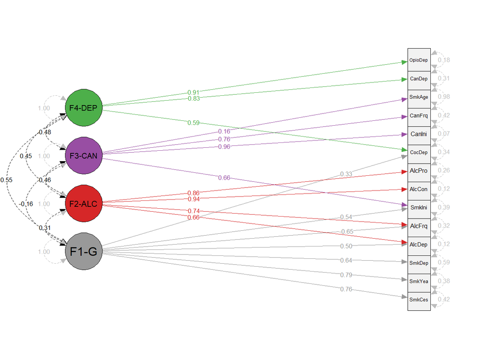

```r
plt <- semPaths(semPlotModel_GSEM(fit),
         layout="tree",
         curve = 2.5,
         whatLabels = "est",
         residuals = T,
         nodeLabels = nodelab,
         edge.color = edge.col,
         color = list(lat = c("grey60", "#D62728", "#984EA3", "#4DAF4A"),
              man = "#f2f2f2"),
         rotation = 2
         ,edge.label.position = c(rep(0.8, 7), rep(0.3, 4), rep(0.4, 4), rep(0.3, 3), rep(0.5, 30))
         )
```

### 20. Per substance - Bifactor index-event adjusted

We now re-fit the best theoretical model (bifactor per-substance) using Hunter-slope adjusted summary statistics for smoking and cannabis traits. Interestingly, the SMK and CAN factors now have a correlation >1, and the bifactor model does not converge (restricting to 1 does not work).

```r
load('data/mldsc_29May2023.hunted.age.14.TOT.RData')

CFA <- 'G =~ NA*PACKYE + SMKCES + SMKDEP + SMKAGE + SMKINI + ALCCON + ALCFRQ + ALCP + ALCDEP + CANEV + CANFL + CANDEP

SMK =~ NA*PACKYE + SMKCES + SMKDEP + SMKAGE + SMKINI
ALC =~ NA*ALCCON + ALCFRQ + ALCP + ALCDEP
CAN =~ NA*CANEV + CANFL + CANDEP

G ~~ 0*SMK + 0*ALC + 0*CAN

G~~1*G
SMK~~1*SMK
ALC~~1*ALC
CAN~~1*CAN

a>.001
 CANEV~~a*CANEV

c>-0.99
  SMK~~c*CAN
'

#run the model
fit <- usermodel(ldscOut, estimation = "DWLS", model = CFA, CFIcalc = TRUE)
```

```r
fitlabel <- paste0("CFI = ", round(fit$modelfit$CFI,3), ", SRMR = ", round(fit$modelfit$SRMR,3))
kable(fitlabel)
```

| x |
| --- |
| CFI = 0.962, SRMR = 0.058 |

**Click to expand table with model parameters**

```r
kable(fit$results)
```

|  | lhs | op | rhs | Unstand_Est | Unstand_SE | STD_Genotype | STD_Genotype_SE | STD_All | p_value |
| --- | --- | --- | --- | --- | --- | --- | --- | --- | --- |
| 29 | G | =~ | PACKYE | 0.2353628 | 0.0111570480150278 | 0.7706853 | 0.035569857332704 | 0.7706853 | 0.0000000 |
| 31 | G | =~ | SMKCES | 0.1892721 | 0.0081649640038201 | 0.7069274 | 0.0306054813873573 | 0.7069274 | 0.0000000 |
| 32 | G | =~ | SMKDEP | 0.2202792 | 0.0187057944142729 | 0.6225289 | 0.052496655393234 | 0.6225288 | 0.0000000 |
| 30 | G | =~ | SMKAGE | -0.0294048 | 0.00666062421737126 | -0.1365962 | 0.0294748396448225 | -0.1365962 | 0.0000101 |
| 33 | G | =~ | SMKINI | 0.1975697 | 0.0116383994393039 | 0.5517610 | 0.0314405544059905 | 0.5517609 | 0.0000000 |
| 22 | G | =~ | ALCCON | 0.1174907 | 0.0121891962292082 | 0.4519557 | 0.0447368689052596 | 0.4519557 | 0.0000000 |
| 24 | G | =~ | ALCFRQ | -0.0938343 | 0.013203732279165 | -0.3299388 | 0.0438231510788101 | -0.3299388 | 0.0000000 |
| 25 | G | =~ | ALCP | 0.0859088 | 0.0125119311051946 | 0.3633918 | 0.0509505016899074 | 0.3633918 | 0.0000000 |
| 23 | G | =~ | ALCDEP | 0.3017158 | 0.0204477968944621 | 0.8133813 | 0.0551491830913568 | 0.8133814 | 0.0000000 |
| 27 | G | =~ | CANEV | 0.0636253 | 0.0401205138875459 | 0.1118278 | 0.0671483736985155 | 0.1108914 | 0.1127721 |
| 28 | G | =~ | CANFL | 0.0586701 | 0.0195362178098429 | 0.2932701 | 0.0956137578192669 | 0.2932666 | 0.0026720 |
| 26 | G | =~ | CANDEP | 0.1778337 | 0.0240034310654996 | 0.6383959 | 0.0859265178238727 | 0.6383945 | 0.0000000 |
| 38 | SMK | =~ | PACKYE | 0.0886187 | 0.0179785244598195 | -0.2535579 | 0.0525896473150197 | -0.2535579 | 0.0000008 |
| 40 | SMK | =~ | SMKCES | 0.0333795 | 0.014362262851797 | -0.1158931 | 0.0457019188844517 | -0.1158931 | 0.0201197 |
| 41 | SMK | =~ | SMKDEP | 0.0627475 | 0.022887609943622 | -0.1505870 | 0.0572340361934096 | -0.1505870 | 0.0061150 |
| 39 | SMK | =~ | SMKAGE | -0.0520867 | 0.00564129198730629 | 0.2265325 | 0.0269487474510006 | 0.2265325 | 0.0000000 |
| 42 | SMK | =~ | SMKINI | -0.1586096 | 0.0196600414219759 | 0.4079298 | 0.0502354084961839 | 0.4079298 | 0.0000000 |
| 3 | ALC | =~ | ALCCON | 0.1993361 | 0.0124770551461139 | 0.7627984 | 0.0453819519710787 | 0.7627983 | 0.0000000 |
| 5 | ALC | =~ | ALCFRQ | 0.2461326 | 0.0128502275026685 | 0.8546216 | 0.0430013896293303 | 0.8546215 | 0.0000000 |
| 6 | ALC | =~ | ALCP | 0.1855030 | 0.0109642358496176 | 0.7818570 | 0.0448718002325467 | 0.7818570 | 0.0000000 |
| 4 | ALC | =~ | ALCDEP | 0.1770562 | 0.0278895072430764 | 0.4775741 | 0.0726925924097995 | 0.4775741 | 0.0000000 |
| 13 | CAN | =~ | CANEV | 0.5796704 | 0.0496139814751915 | 1.0017258 | 0.0855899205556807 | 0.9933377 | 0.0000000 |
| 14 | CAN | =~ | CANFL | 0.1491637 | 0.0176561415979257 | 0.7323445 | 0.086513312576089 | 0.7323358 | 0.0000000 |
| 12 | CAN | =~ | CANDEP | 0.0859387 | 0.0261945729966384 | 0.3076745 | 0.0909595439675183 | 0.3076739 | 0.0010352 |
| 16 | CANEV | ~~ | CANEV | 0.0009993 | 0.054080060936555 | 0.0009999 | 0.161031045350536 | 0.0009999 | 0.9852578 |
| 36 | SMK | ~~ | CAN | -0.9900002 | 0.103595182736077 | 1.1675201 | 0.132814472819987 | 1.1675201 | 0.0000000 |
| 46 | SMKINI | ~~ | SMKINI | 0.0545359 | 0.00507326513826647 | 0.5291532 | 0.0384398845799548 | 0.5291532 | 0.0000000 |
| 44 | SMKCES | ~~ | SMKCES | 0.0360780 | 0.00345412218977625 | 0.4868225 | 0.047352885214845 | 0.4868225 | 0.0000000 |
| 34 | PACKYE | ~~ | PACKYE | 0.0285253 | 0.00585484460949551 | 0.3417526 | 0.0611384392212853 | 0.3417526 | 0.0000011 |
| 43 | SMKAGE | ~~ | SMKAGE | 0.0417751 | 0.0025818781623118 | 0.9300246 | 0.0570047425275107 | 0.9300245 | 0.0000000 |
| 45 | SMKDEP | ~~ | SMKDEP | 0.0725199 | 0.0172163693663225 | 0.5897815 | 0.137327721566458 | 0.5897814 | 0.0000253 |
| 7 | ALCCON | ~~ | ALCCON | 0.0153466 | 0.00273792722362924 | 0.2138747 | 0.0391280886465193 | 0.2138747 | 0.0000000 |
| 9 | ALCFRQ | ~~ | ALCFRQ | 0.0129628 | 0.00467987211485987 | 0.1607625 | 0.0549121772046644 | 0.1607625 | 0.0056074 |
| 10 | ALCP | ~~ | ALCP | 0.0148000 | 0.00345252012595223 | 0.2566461 | 0.0611892548160855 | 0.2566461 | 0.0000181 |
| 8 | ALCDEP | ~~ | ALCDEP | 0.0170066 | 0.0268014487382296 | 0.1103336 | 0.19282745776365 | 0.1103336 | 0.5257281 |
| 15 | CANDEP | ~~ | CANDEP | 0.0393768 | 0.0269751527639649 | 0.4977915 | 0.344013161788989 | 0.4977893 | 0.1443602 |
| 17 | CANFL | ~~ | CANFL | 0.0147926 | 0.01552032177386 | 0.3776881 | 0.38288798825289 | 0.3776790 | 0.3405324 |
| 35 | SMK | ~~ | ALC | -0.6199992 | 0.05683053941165 | 0.6999775 | 0.0713129866629367 | 0.6999775 | 0.0000000 |
| 2 | ALC | ~~ | CAN | 0.4536546 | 0.0443165098269255 | 0.4573445 | 0.044550166110583 | 0.4573445 | 0.0000000 |
| 21 | G | ~~ | SMK | 0.0000000 |  | 0.0000000 |  | 0.0000000 | NA |
| 18 | G | ~~ | ALC | 0.0000000 |  | 0.0000000 |  | 0.0000000 | NA |
| 19 | G | ~~ | CAN | 0.0000000 |  | 0.0000000 |  | 0.0000000 | NA |
| 20 | G | ~~ | G | 1.0000000 |  | 1.0000000 |  | 1.0000000 | NA |
| 37 | SMK | ~~ | SMK | 1.0000000 |  | 1.0000000 |  | 1.0000000 | NA |
| 1 | ALC | ~~ | ALC | 1.0000000 |  | 1.0000000 |  | 1.0000000 | NA |
| 11 | CAN | ~~ | CAN | 1.0000000 |  | 1.0000000 |  | 1.0000000 | NA |

#### Plot Per substance - Bifactor index-event adjusted

```r
nodelab <- c("SmkYea", "SmkCes", "SmkDep", "SmkAge", "SmkIni",
             "AlcCon", "AlcFrq", "AlcPro", "AlcDep",
             "CanIni", "CanFrq", "CanDep",
             "G", "SMK", "ALC", "CAN")

edge.col <- c(rep("grey60",12),
              rep("#377EB8",5),
              rep("#984EA3",4),
              rep("#4DAF4A",3),
              "grey", "black",
              rep("grey", 11),
              rep("black", 2),
              rep("white", 3),
              rep("grey", 4))


fit$results <- fit$results %>%
  mutate(STD_Genotype = ifelse(Unstand_Est > 0 & STD_Genotype < 0, -1 * STD_Genotype, STD_Genotype),
         STD_Genotype = ifelse(Unstand_Est < 0 & STD_Genotype > 0, -1 * STD_Genotype, STD_Genotype))


svg("results/semplot_per-sub_bifactor_adjusted.svg", width = 10, height = 8)

semPaths(semPlotModel_GSEM(fit),
         layout="tree",
         curve = 2.5,
         whatLabels = "est",
         residuals = T,
         nodeLabels = nodelab,
         edge.color = edge.col,
         color = list(lat = c("grey60", "#377EB8", "#984EA3", "#4DAF4A"),
              man = "#f2f2f2"),
         rotation = 2,
         edge.label.position = c(rep(0.8, 12), rep(0.6, 5), rep(0.4, 4), rep(0.2, 3), rep(0.5, 28))
         )

dev.off()
```

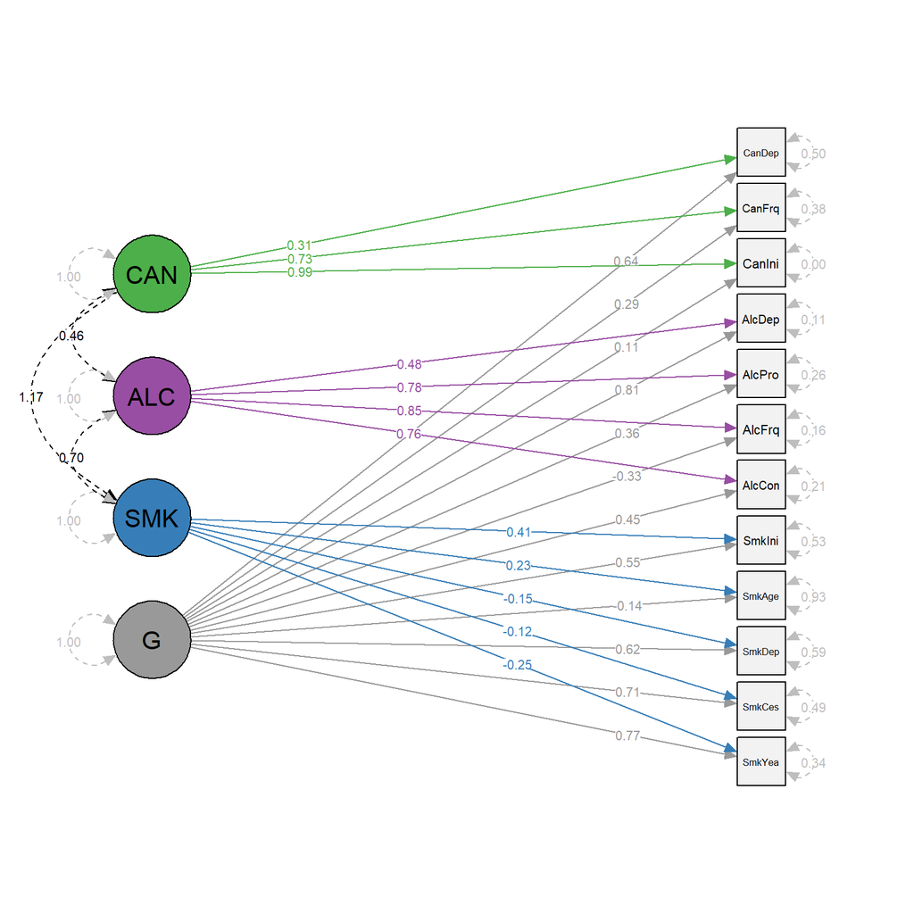

```r
semPaths(semPlotModel_GSEM(fit),
         layout="tree",
         curve = 2.5,
         whatLabels = "est",
         residuals = T,
         nodeLabels = nodelab,
         edge.color = edge.col,
         color = list(lat = c("grey60", "#377EB8", "#984EA3", "#4DAF4A"),
              man = "#f2f2f2"),
         rotation = 2,
         edge.label.position = c(rep(0.8, 12), rep(0.6, 5), rep(0.4, 4), rep(0.2, 3), rep(0.5, 28))
         )
```

### 27. Per stage - Bifactor index-event adjusted

These are the results for the adjusted model per stage. The fit is pretty similar to that of the unadjusted model.

```r
load('data/mldsc_29May2023.hunted.age.14.TOT.RData')

CFA <- 'G =~ NA*SMKINI + SMKAGE + CANEV + PACKYE + ALCCON + ALCFRQ + ALCP + CANFL + SMKDEP + ALCDEP + CANDEP + COCDEP + OPIODEP

INI =~ NA*SMKINI + SMKAGE + CANEV
FRQ =~ NA*PACKYE + ALCCON + ALCFRQ + ALCP + CANFL
DEP =~ NA*SMKDEP + ALCDEP + CANDEP + COCDEP + OPIODEP

G ~~ 0*INI + 0*FRQ + 0*DEP

G~~1*G
INI~~1*INI
FRQ~~1*FRQ
DEP~~1*DEP
'

#run the model
fit <- usermodel(ldscOut, estimation = "DWLS", model = CFA, CFIcalc = TRUE)
```

```r
fitlabel <- paste0("CFI = ", round(fit$modelfit$CFI,3), ", SRMR = ", round(fit$modelfit$SRMR,3), ", AIC = ", round(fit$modelfit$AIC), ", Chisq = ", round(fit$modelfit$chisq))
kable(fitlabel)
```

| x |
| --- |
| CFI = 0.961, SRMR = 0.104, AIC = 463, Chisq = 379 |

**Click to expand table with model parameters**

```r
kable(fit$results)
```

|  | lhs | op | rhs | Unstand_Est | Unstand_SE | STD_Genotype | STD_Genotype_SE | STD_All | p_value |
| --- | --- | --- | --- | --- | --- | --- | --- | --- | --- |
| 38 | G | =~ | SMKINI | 0.1180295 | 0.0169968983250214 | 0.3419760 | 0.0492465336051303 | 0.3419760 | 0.0000000 |
| 36 | G | =~ | SMKAGE | -0.0724420 | 0.00662424587535953 | -0.3372442 | 0.0308383226588915 | -0.3372442 | 0.0000000 |
| 31 | G | =~ | CANEV | -0.1045447 | 0.0355367975358262 | -0.1823020 | 0.0619680031905441 | -0.1823020 | 0.0032624 |
| 35 | G | =~ | PACKYE | 0.2256466 | 0.010413395914171 | 0.7447229 | 0.0343683252383906 | 0.7447228 | 0.0000000 |
| 26 | G | =~ | ALCCON | 0.0402204 | 0.0214692341855538 | 0.1531670 | 0.0817592437245103 | 0.1531670 | 0.0610133 |
| 28 | G | =~ | ALCFRQ | -0.1698763 | 0.0179025400882338 | -0.5901477 | 0.062193158470093 | -0.5901477 | 0.0000000 |
| 29 | G | =~ | ALCP | 0.0065813 | 0.0197900375001152 | 0.0275116 | 0.0827296700042132 | 0.0275116 | 0.7394700 |
| 32 | G | =~ | CANFL | 0.0212151 | 0.0182170625404989 | 0.1042414 | 0.089508193712664 | 0.1042413 | 0.2441912 |
| 37 | G | =~ | SMKDEP | 0.2232669 | 0.0219904937178396 | 0.6313157 | 0.0621809516095336 | 0.6313159 | 0.0000000 |
| 27 | G | =~ | ALCDEP | 0.1920605 | 0.0327479338943562 | 0.5055803 | 0.0862060548976273 | 0.5055805 | 0.0000000 |
| 30 | G | =~ | CANDEP | 0.1394794 | 0.0269139110629998 | 0.4784355 | 0.0923188703563011 | 0.4784353 | 0.0000002 |
| 33 | G | =~ | COCDEP | 0.3495939 | 0.0384744136401784 | 0.6406166 | 0.0705029489148748 | 0.6406156 | 0.0000000 |
| 34 | G | =~ | OPIODEP | 0.2252168 | 0.0445436503229157 | 0.5038828 | 0.0996584698413866 | 0.5038828 | 0.0000004 |
| 44 | INI | =~ | SMKINI | 0.2564232 | 0.0167611679943519 | 0.7429558 | 0.0485634777055219 | 0.7429557 | 0.0000000 |
| 43 | INI | =~ | SMKAGE | 0.0345554 | 0.00751750811101572 | 0.1608678 | 0.0349968121542321 | 0.1608678 | 0.0000043 |
| 42 | INI | =~ | CANEV | 0.4746019 | 0.0295944181362607 | 0.8275958 | 0.0516058558287241 | 0.8275959 | 0.0000000 |
| 21 | FRQ | =~ | PACKYE | -0.0255558 | 0.0226273584208745 | -0.0843447 | 0.0746792733248037 | -0.0843447 | 0.2587207 |
| 17 | FRQ | =~ | ALCCON | -0.2401282 | 0.00907160369845891 | -0.9144564 | 0.0345464768166382 | -0.9144564 | 0.0000000 |
| 18 | FRQ | =~ | ALCFRQ | -0.1766016 | 0.0172099702423018 | -0.6135106 | 0.0597872244761777 | -0.6135106 | 0.0000000 |
| 19 | FRQ | =~ | ALCP | -0.2087696 | 0.0087978325586002 | -0.8727329 | 0.0367781670824425 | -0.8727324 | 0.0000000 |
| 20 | FRQ | =~ | CANFL | -0.1146979 | 0.0180670803167744 | -0.5635592 | 0.0887712664278577 | -0.5635592 | 0.0000000 |
| 14 | DEP | =~ | SMKDEP | -0.0407516 | 0.0246336097799237 | -0.1152310 | 0.0696547536020475 | -0.1152310 | 0.0980645 |
| 10 | DEP | =~ | ALCDEP | -0.2931499 | 0.0386480560088122 | -0.7716922 | 0.101737398280537 | -0.7716926 | 0.0000000 |
| 11 | DEP | =~ | CANDEP | -0.1461031 | 0.0280974490172493 | -0.5011565 | 0.0963785325438321 | -0.5011563 | 0.0000002 |
| 12 | DEP | =~ | COCDEP | -0.2447886 | 0.0493766728375429 | -0.4485668 | 0.0904808666448376 | -0.4485661 | 0.0000007 |
| 13 | DEP | =~ | OPIODEP | -0.2648292 | 0.0474244740185047 | -0.5925084 | 0.106103783090511 | -0.5925084 | 0.0000000 |
| 49 | SMKINI | ~~ | SMKINI | 0.0394375 | 0.0053474063321482 | 0.3310692 | 0.0448904948791573 | 0.3310692 | 0.0000000 |
| 46 | PACKYE | ~~ | PACKYE | 0.0402359 | 0.00567838277179847 | 0.4382740 | 0.0618523647086086 | 0.4382739 | 0.0000000 |
| 47 | SMKAGE | ~~ | SMKAGE | 0.0396995 | 0.0025123089377766 | 0.8603876 | 0.0544479907033911 | 0.8603879 | 0.0000000 |
| 48 | SMKDEP | ~~ | SMKDEP | 0.0735620 | 0.0175094900150399 | 0.5881616 | 0.139996716349964 | 0.5881620 | 0.0000265 |
| 1 | ALCCON | ~~ | ALCCON | 0.0096749 | 0.0027642836229309 | 0.1403093 | 0.0400887271774402 | 0.1403093 | 0.0004653 |
| 3 | ALCFRQ | ~~ | ALCFRQ | 0.0228139 | 0.00390439247580511 | 0.2753305 | 0.0471204082569268 | 0.2753305 | 0.0000000 |
| 4 | ALCP | ~~ | ALCP | 0.0135950 | 0.003493075831818 | 0.2375815 | 0.0610431206057976 | 0.2375812 | 0.0000994 |
| 2 | ALCDEP | ~~ | ALCDEP | 0.0214847 | 0.0277691142046105 | 0.1488787 | 0.192428473229514 | 0.1488789 | 0.4391142 |
| 6 | CANEV | ~~ | CANEV | 0.0926913 | 0.0227917043563399 | 0.2818510 | 0.0693034492166767 | 0.2818510 | 0.0000476 |
| 5 | CANDEP | ~~ | CANDEP | 0.0441902 | 0.027804142191467 | 0.5199423 | 0.327142205496463 | 0.5199420 | 0.1119837 |
| 7 | CANFL | ~~ | CANFL | 0.0278163 | 0.0154478519691997 | 0.6715348 | 0.372938243299812 | 0.6715348 | 0.0717571 |
| 8 | COCDEP | ~~ | COCDEP | 0.1156662 | 0.0514629778501808 | 0.3884013 | 0.1728085147003 | 0.3884001 | 0.0246042 |
| 45 | OPIODEP | ~~ | OPIODEP | 0.0789186 | 0.0697408986026011 | 0.3950359 | 0.349095858564099 | 0.3950359 | 0.2578041 |
| 40 | INI | ~~ | FRQ | -0.5883390 | 0.0266341207776289 | -0.5883392 | 0.0266341357006179 | -0.5883392 | 0.0000000 |
| 39 | INI | ~~ | DEP | -0.8499808 | 0.0951303596529511 | -0.8499803 | 0.0951300676981607 | -0.8499803 | 0.0000000 |
| 15 | FRQ | ~~ | DEP | 0.7783743 | 0.108315713253151 | 0.7783731 | 0.10831537695336 | 0.7783731 | 0.0000000 |
| 25 | G | ~~ | INI | 0.0000000 |  | 0.0000000 |  | 0.0000000 | NA |
| 23 | G | ~~ | FRQ | 0.0000000 |  | 0.0000000 |  | 0.0000000 | NA |
| 22 | G | ~~ | DEP | 0.0000000 |  | 0.0000000 |  | 0.0000000 | NA |
| 24 | G | ~~ | G | 1.0000000 |  | 1.0000000 |  | 1.0000000 | NA |
| 41 | INI | ~~ | INI | 1.0000000 |  | 1.0000000 |  | 1.0000000 | NA |
| 16 | FRQ | ~~ | FRQ | 1.0000000 |  | 1.0000000 |  | 1.0000000 | NA |
| 9 | DEP | ~~ | DEP | 1.0000000 |  | 1.0000000 |  | 1.0000000 | NA |

```r
fwrite(fit$results, "results/modeloutput/pertrait_bifactor_indexevent.csv")
```

#### Plot Per stage - Bifactor index-event adjusted

```r
nodelab <- c("SmkIni", "SmkAge", "CanIni",
             "SmkYea", "AlcCon", "AlcFrq", "AlcPro", "CanFrq",
             "SmkDep", "AlcDep", "CanDep", "CocDep", "OpioDep",
             "G", "INI", "FRQ", "DEP")

edge.col <- c(rep("grey60", 13),
              rep("#FF7F00", 3),
              rep("#17BECF", 5),
              rep("#D62728", 5),
              rep("grey", 13),
              rep("black", 3),
              rep("white", 3),
              rep("grey", 4))



svg("results/semplot_per-type_bifactor_adjusted.svg", width = 8, height = 8)

semPaths(semPlotModel_GSEM(fit),
         layout="tree",
         curve = 2.5,
         whatLabels = "est",
         residuals = T,
         nodeLabels = nodelab,
         edge.color = edge.col,
         color = list(lat = c("grey60", "#FF7F00", "#17BECF", "#D62728"),
              man = "#f2f2f2"),
         rotation = 2,
         edge.label.position = c(rep(0.8, 13), rep(0.4, 3), rep(0.4, 5), rep(0.4, 5), rep(0.5, 29))
         )

dev.off()
```

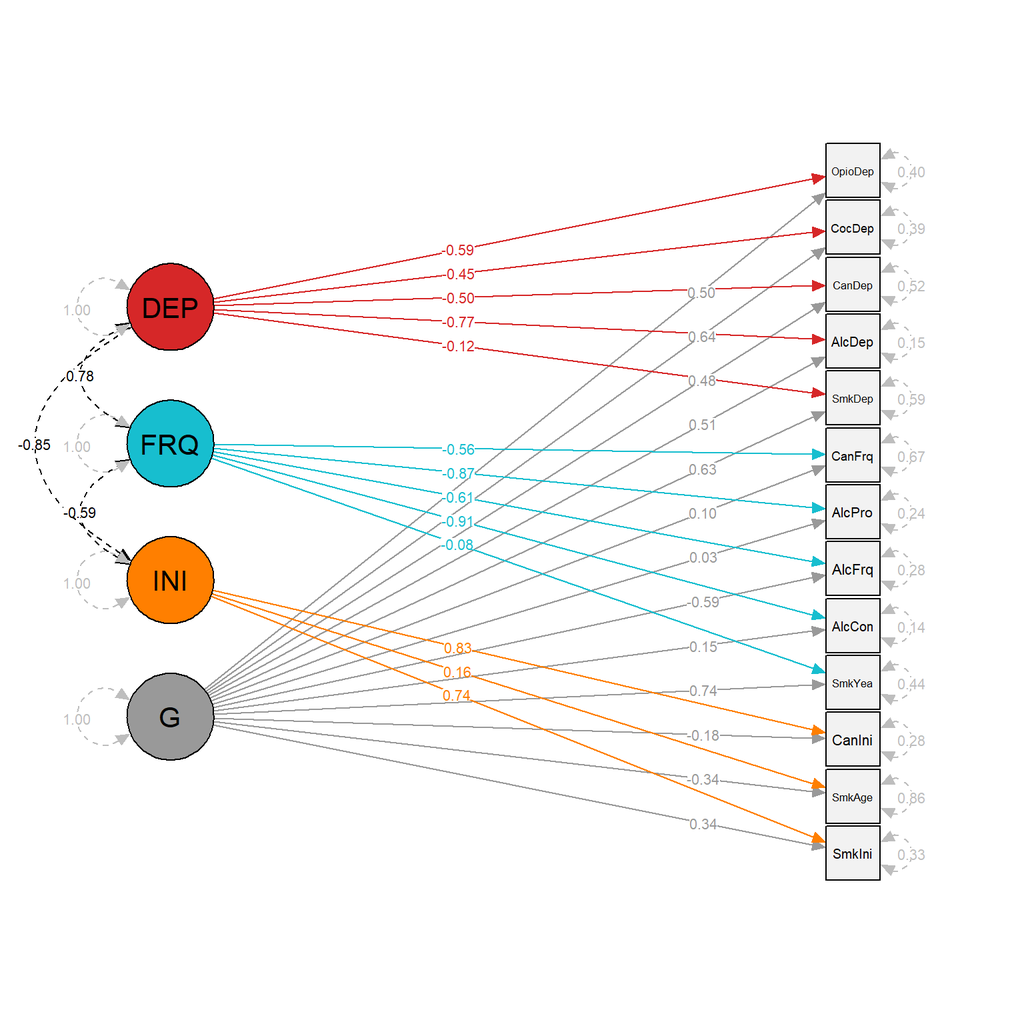

```r
semPaths(semPlotModel_GSEM(fit),
         layout="tree",
         curve = 2.5,
         whatLabels = "est",
         residuals = T,
         nodeLabels = nodelab,
         edge.color = edge.col,
         color = list(lat = c("grey60", "#FF7F00", "#17BECF", "#D62728"),
              man = "#f2f2f2"),
         rotation = 2,
         edge.label.position = c(rep(0.8, 13), rep(0.4, 3), rep(0.4, 5), rep(0.4, 5), rep(0.5, 29))
         )
```

# HDL

### 10. EFA 4 factor - HDL

In addition, we explore the factor structure in the HDL-based covariance matrix. Note that opioid dependence is excluded (because its variance couldn’t be estimated with HDL), which will account for some of the difference in the factor structure.

EFA:

```r
load("data/hdl_10January2024.14.RData")

Ssmooth <- as.matrix((nearPD(hdlOut$S, corr = FALSE))$mat)

EFA <-factanal(covmat = Ssmooth, factors = 4, rotation = 'promax')
```

```r
print(EFA, digits = 2, cutoff = .3, sort = TRUE)
```

```
##
## Call:
## factanal(factors = 4, covmat = Ssmooth, rotation = "promax")
##
## Uniquenesses:
## SMKINI SMKCES PACKYE SMKAGE SMKDEP ALCCON ALCFRQ   ALCP ALCDEP  CANEV CANDEP
##   0.16   0.06   0.06   0.29   0.00   0.04   0.35   0.03   0.00   0.00   0.75
##  CANFL COCDEP
##   0.17   0.00
##
## Loadings:
##        Factor1 Factor2 Factor3 Factor4
## SMKAGE -0.61
## SMKDEP  0.63    0.45
## ALCDEP  0.92
## COCDEP  1.02
## SMKCES          1.10
## PACKYE          0.86
## ALCCON  0.48            0.89
## ALCFRQ -0.31            0.66
## ALCP                    0.87
## SMKINI                          0.72
## CANEV                   0.37    0.71
## CANFL                           0.91
## CANDEP                          0.41
##
##                Factor1 Factor2 Factor3 Factor4
## SS loadings       3.14    2.40    2.32    2.23
## Proportion Var    0.24    0.18    0.18    0.17
## Cumulative Var    0.24    0.43    0.60    0.78
##
## Factor Correlations:
##         Factor1 Factor2 Factor3 Factor4
## Factor1    1.00   -0.13   -0.72   -0.46
## Factor2   -0.13    1.00   -0.14    0.43
## Factor3   -0.72   -0.14    1.00    0.12
## Factor4   -0.46    0.43    0.12    1.00
##
## The degrees of freedom for the model is 32 and the fit was 47.7409
```

The fit is quite similar to the LDSC-based models, but the structure is surprisingly distinct (though this will in part be due to the exclusion of opioid dependence).

```r
load("data/hdl_10January2024.14.RData")

CFA <- '
F1 =~ NA*SMKAGE + SMKDEP + ALCDEP + COCDEP + ALCCON + ALCFRQ
F2 =~ NA*SMKDEP + SMKCES + PACKYE
F3 =~ NA*ALCCON + ALCFRQ + ALCP + CANEV
F4 =~ NA*SMKINI + CANEV + CANFL + CANDEP

F1~~1*F1
F2~~1*F2
F3~~1*F3
F4~~1*F4

a > .001
  SMKINI ~~ a*SMKINI

b>.001
  SMKDEP ~~ b*SMKDEP

c>.001
  ALCDEP ~~  c*ALCDEP
'

#run the model
fit <- usermodel(hdlOut, estimation = "DWLS", model = CFA, CFIcalc = TRUE)
```

```r
fitlabel <- paste0("CFI = ", round(fit$modelfit$CFI,3), ", SRMR = ", round(fit$modelfit$SRMR,3), ", AIC = ", round(fit$modelfit$AIC), ", Chisq = ", round(fit$modelfit$chisq))
kable(fitlabel)
```

| x |
| --- |
| CFI = 0.898, SRMR = 0.123, AIC = 132407000, Chisq = 132406928 |

**Click to expand table with model parameters**

```r
kable(fit$results)
```

|  | lhs | op | rhs | Unstand_Est | Unstand_SE | STD_Genotype | STD_Genotype_SE | STD_All | p_value |
| --- | --- | --- | --- | --- | --- | --- | --- | --- | --- |
| 17 | F1 | =~ | SMKAGE | 0.1352343 | 0.00843884408661771 | 0.7609734 | 0.0474933786691975 | 0.7609734 | 0.0000000 |
| 18 | F1 | =~ | SMKDEP | -0.1377658 | 0.0263507000468433 | -0.6116406 | 0.117255785741458 | -0.6081942 | 0.0000002 |
| 14 | F1 | =~ | ALCDEP | -0.3002740 | 0.0164467198301705 | -0.9945520 | 0.054481263152691 | -0.9945520 | 0.0000000 |
| 16 | F1 | =~ | COCDEP | -0.3504548 | 0.0241971932485635 | -0.9642504 | 0.0665812440098375 | -0.9642506 | 0.0000000 |
| 13 | F1 | =~ | ALCCON | -0.0598493 | 0.00980671429424724 | -0.2256815 | 0.0369686918937779 | -0.2256815 | 0.0000000 |
| 15 | F1 | =~ | ALCFRQ | 0.1670370 | 0.019960534574663 | 0.5532499 | 0.0660907740194184 | 0.5532498 | 0.0000000 |
| 24 | F2 | =~ | SMKDEP | 0.1015842 | 0.0351364488941422 | 0.4580303 | 0.156323519019764 | 0.4554494 | 0.0038385 |
| 23 | F2 | =~ | SMKCES | 0.1862169 | 0.0102819064971622 | 0.8884381 | 0.0490800773400977 | 0.8884384 | 0.0000000 |
| 22 | F2 | =~ | PACKYE | 0.2749508 | 0.013501671977309 | 0.9880385 | 0.048558473520411 | 0.9880387 | 0.0000000 |
| 27 | F3 | =~ | ALCCON | 0.1707673 | 0.00933045902258803 | 0.6438145 | 0.0351788946190547 | 0.6438145 | 0.0000000 |
| 28 | F3 | =~ | ALCFRQ | 0.2807570 | 0.0191340896231652 | 0.9300838 | 0.0633559378280359 | 0.9300836 | 0.0000000 |
| 29 | F3 | =~ | ALCP | 0.2025331 | 0.00887362603450769 | 0.9671248 | 0.0423689956188157 | 0.9671248 | 0.0000000 |
| 30 | F3 | =~ | CANEV | 0.2586280 | 0.023220489706966 | 0.7550884 | 0.0677944511225962 | 0.7550884 | 0.0000000 |
| 35 | F4 | =~ | SMKINI | 0.3357918 | 0.0180574048721914 | 0.9765322 | 0.0525146580818949 | 0.9765320 | 0.0000000 |
| 33 | F4 | =~ | CANEV | 0.0787872 | 0.0240538152652031 | 0.2301188 | 0.0702269805134632 | 0.2301188 | 0.0010549 |
| 34 | F4 | =~ | CANFL | 0.1359653 | 0.0112562960424988 | 0.5780961 | 0.0478581365844749 | 0.5780961 | 0.0000000 |
| 32 | F4 | =~ | CANDEP | 0.1559533 | 0.0192238272088436 | 0.3461911 | 0.0426753134055466 | 0.3461911 | 0.0000000 |
| 40 | SMKINI | ~~ | SMKINI | 0.0054840 | 0.0121907673983398 | 0.0463853 | 0.103102983659121 | 0.0463853 | 0.6528168 |
| 39 | SMKDEP | ~~ | SMKDEP | 0.0009995 | 0.00725183050126806 | 0.0010002 | 0.14413327018071 | 0.0010002 | 0.8903791 |
| 2 | ALCDEP | ~~ | ALCDEP | 0.0010008 | 0.00996779299326002 | 0.0108663 | 0.109348228254339 | 0.0108663 | 0.9200248 |
| 38 | SMKCES | ~~ | SMKCES | 0.0092217 | 0.0043245827974583 | 0.2106771 | 0.0985103204994405 | 0.2106772 | 0.0329749 |
| 36 | PACKYE | ~~ | PACKYE | 0.0017737 | 0.00619573948028528 | 0.0237795 | 0.0800505598496052 | 0.0237795 | 0.7746712 |
| 37 | SMKAGE | ~~ | SMKAGE | 0.0132832 | 0.00231488344351053 | 0.4209194 | 0.0733154583263673 | 0.4209194 | 0.0000000 |
| 1 | ALCCON | ~~ | ALCCON | 0.0286438 | 0.00317357856761666 | 0.4070980 | 0.045107337901978 | 0.4070981 | 0.0000000 |
| 3 | ALCFRQ | ~~ | ALCFRQ | 0.0255119 | 0.00631074300702672 | 0.2803030 | 0.0692257036692177 | 0.2803029 | 0.0000529 |
| 4 | ALCP | ~~ | ALCP | 0.0028434 | 0.00431977759374513 | 0.0646697 | 0.0984746767727682 | 0.0646697 | 0.5103862 |
| 6 | CANEV | ~~ | CANEV | 0.0207394 | 0.0113094944456401 | 0.1768061 | 0.0964124785761015 | 0.1768061 | 0.0666836 |
| 5 | CANDEP | ~~ | CANDEP | 0.1786252 | 0.0213191807645557 | 0.8801517 | 0.10504872863448 | 0.8801517 | 0.0000000 |
| 7 | CANFL | ~~ | CANFL | 0.0368329 | 0.0071388106654088 | 0.6658049 | 0.129052135297456 | 0.6658049 | 0.0000002 |
| 8 | COCDEP | ~~ | COCDEP | 0.0092695 | 0.0244716794575411 | 0.0702209 | 0.185250796884034 | 0.0702209 | 0.7048468 |
| 10 | F1 | ~~ | F2 | -0.7609127 | 0.0368736295656446 | -0.7611447 | 0.0369518601780681 | -0.7611447 | 0.0000000 |
| 11 | F1 | ~~ | F3 | -0.4386330 | 0.0441634251912548 | -0.4386624 | 0.0441394657315905 | -0.4386624 | 0.0000000 |
| 12 | F1 | ~~ | F4 | -0.7352867 | 0.0490922992363414 | -0.7351651 | 0.0490908516229038 | -0.7351651 | 0.0000000 |
| 20 | F2 | ~~ | F3 | 0.0875714 | 0.0448015814497673 | 0.0875408 | 0.0447985843289469 | 0.0875408 | 0.0506243 |
| 21 | F2 | ~~ | F4 | 0.3712308 | 0.0334549892412114 | 0.3712082 | 0.0334777296692296 | 0.3712082 | 0.0000000 |
| 26 | F3 | ~~ | F4 | 0.5758524 | 0.0449144884275903 | 0.5757388 | 0.0449066567996519 | 0.5757388 | 0.0000000 |
| 9 | F1 | ~~ | F1 | 1.0000000 |  | 1.0000000 |  | 1.0000000 | NA |
| 19 | F2 | ~~ | F2 | 1.0000000 |  | 1.0000000 |  | 1.0000000 | NA |
| 25 | F3 | ~~ | F3 | 1.0000000 |  | 1.0000000 |  | 1.0000000 | NA |
| 31 | F4 | ~~ | F4 | 1.0000000 |  | 1.0000000 |  | 1.0000000 | NA |

```r
fwrite(fit$results, "results/modeloutput/EFA4factor_HDL.csv")
```

#### Plot EFA 4 factor - HDL

```r
nodelab <- c( "SmkAge", "AlcDep", "CocDep", "SmkDep",
              "AlcCon", "AlcFrq", "SmkCes", "SmkYe",
              "AlcPro", "CanIni", "SmkIni", "CanFrq", "CanDep",

              "F1", "F2", "F3", "F4")

edge.col <- c(rep("#bebada",6),
              rep("#fb8072",3),
              rep("#bc80bd",4),
              rep("#fdb462",4),
              rep("grey",13),
              rep("black",6),
              rep("grey",4))


svg("results/semplot_4F_hdl.svg", width = 10, height = 7)


semPaths(semPlotModel_GSEM(fit),
         layout="tree",
         curve = 2.5,
         whatLabels = "est",
         residuals = T,
         nodeLabels = nodelab,
         edge.color = edge.col,
         color = list(lat = c("#bebada", "#fb8072", "#fdb462", "#bc80bd"),
              man = "#f2f2f2"),
         rotation = 2
         ,edge.label.position = c(rep(0.8, 6), rep(0.3, 3), rep(0.4, 4), rep(0.3, 4), rep(0.5, 29))
         )

dev.off()
```

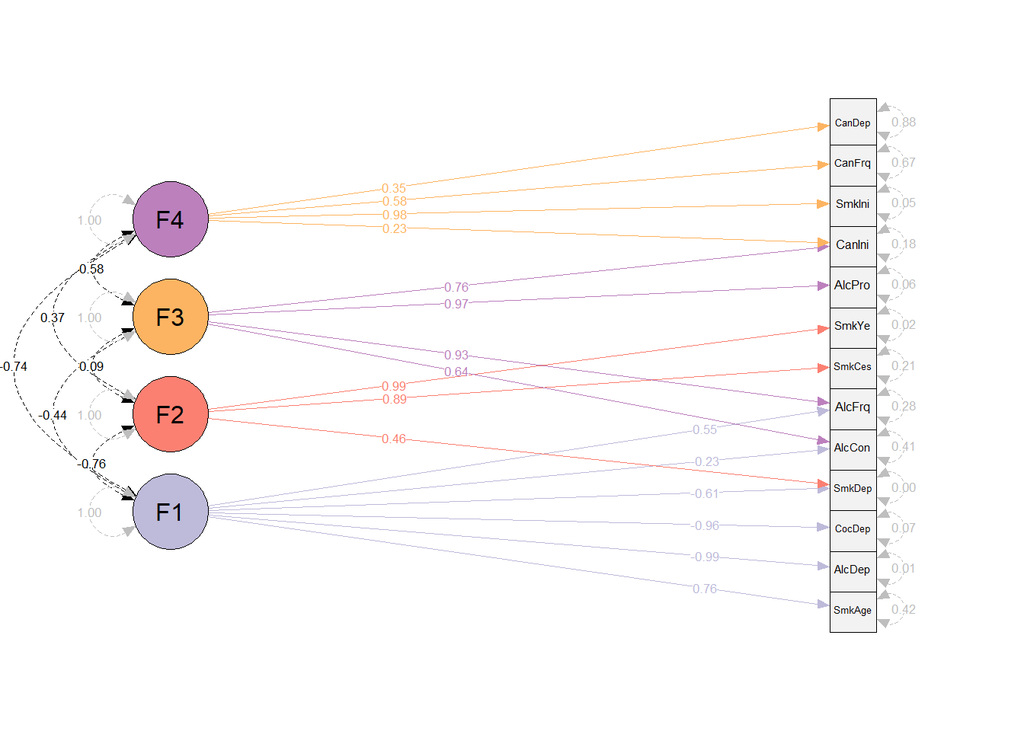

```r
semPaths(semPlotModel_GSEM(fit),
         layout="tree",
         curve = 2.5,
         whatLabels = "est",
         residuals = T,
         nodeLabels = nodelab,
         edge.color = edge.col,
         color = list(lat = c("#bebada", "#fb8072", "#fdb462", "#bc80bd"),
              man = "#f2f2f2"),
         rotation = 2
         ,edge.label.position = c(rep(0.8, 6), rep(0.3, 3), rep(0.4, 4), rep(0.3, 4), rep(0.5, 29))
         )
```

### 19. Per substance - Bifactor HDL

Now we repeat the model that fit the data best (bifactor - per substance) with an HDL-based covariance structure (instead of LDSC). The covariance of opioid dependence could not be estimated and is not included in these models. Therefore, there is no DRG factor and COCDEP is included only in the general G factor. As with the bias-adjusted model, the correlation between SMK and CAN has to be restricted <.99. The fit of the S-1 model without the SMK factor is bad, and CANDEP does not load on the cannabis factor.

```r
load("data/hdl_10January2024.14.RData")

bif <- 'G =~ NA*PACKYE + SMKCES + SMKDEP + SMKAGE + SMKINI + ALCCON + ALCFRQ + ALCP + ALCDEP + CANEV + CANFL + CANDEP + COCDEP

SMK =~ NA*PACKYE + SMKCES + SMKDEP + SMKAGE + SMKINI
ALC =~ NA*ALCCON + ALCFRQ + ALCP + ALCDEP
CAN =~ NA*CANEV + CANFL + CANDEP

G ~~ 0*SMK + 0*ALC + 0*CAN

G~~1*G
SMK~~1*SMK
ALC~~1*ALC
CAN~~1*CAN

a>.001
   ALCP~~a*ALCP

b>.001
  CANEV~~b*CANEV

c>-.99
  CAN~~c*SMK
'

#run the model
fit <- usermodel(hdlOut, estimation = "DWLS", model = bif, CFIcalc = TRUE)
```

```r
fitlabel <- paste0("CFI = ", round(fit$modelfit$CFI,3), ", SRMR = ", round(fit$modelfit$SRMR,3), ", AIC = ", round(fit$modelfit$AIC), ", Chisq = ", round(fit$modelfit$chisq))
kable(fitlabel)
```

| x |
| --- |
| CFI = 0.965, SRMR = 0.061, AIC = 44878280, Chisq = 44878198 |

**Click to expand table with model parameters**

```r
kable(fit$results)
```

|  | lhs | op | rhs | Unstand_Est | Unstand_SE | STD_Genotype | STD_Genotype_SE | STD_All | p_value |
| --- | --- | --- | --- | --- | --- | --- | --- | --- | --- |
| 31 | G | =~ | PACKYE | 0.2243239 | 0.0113945333508686 | 0.7928124 | 0.0388233709873164 | 0.7928123 | 0.0000000 |
| 33 | G | =~ | SMKCES | 0.1537877 | 0.0102849923014753 | 0.7254978 | 0.0478249543406626 | 0.7254977 | 0.0000000 |
| 34 | G | =~ | SMKDEP | 0.2248905 | 0.0161370555483184 | 1.0026783 | 0.0712933472533756 | 1.0026784 | 0.0000000 |
| 32 | G | =~ | SMKAGE | -0.1391901 | 0.00894775508887698 | -0.7863442 | 0.050575711865108 | -0.7863443 | 0.0000000 |
| 35 | G | =~ | SMKINI | 0.2500180 | 0.0101370443135437 | 0.7069635 | 0.0289928844280495 | 0.7069634 | 0.0000000 |
| 23 | G | =~ | ALCCON | 0.1289999 | 0.0100014596177058 | 0.5049029 | 0.0361713957161467 | 0.5049029 | 0.0000000 |
| 25 | G | =~ | ALCFRQ | -0.0491132 | 0.0112386532324408 | -0.1474482 | 0.0369491809632531 | -0.1474482 | 0.0000124 |
| 26 | G | =~ | ALCP | 0.0898807 | 0.0110895662111076 | 0.4525240 | 0.0514238470848852 | 0.4525239 | 0.0000000 |
| 24 | G | =~ | ALCDEP | 0.2780280 | 0.0159413224194723 | 0.9389714 | 0.0526079533676842 | 0.9389714 | 0.0000000 |
| 28 | G | =~ | CANEV | 0.1505560 | 0.0257427470715993 | 0.4861975 | 0.075547766885279 | 0.4705250 | 0.0000000 |
| 29 | G | =~ | CANFL | 0.0726529 | 0.0144537035344586 | 0.3352880 | 0.0623993325366831 | 0.3352874 | 0.0000005 |
| 27 | G | =~ | CANDEP | 0.1647938 | 0.0208407587860828 | 0.3708915 | 0.0462373985406529 | 0.3708915 | 0.0000000 |
| 30 | G | =~ | COCDEP | 0.3404901 | 0.0224241865533724 | 0.9464214 | 0.0623843162238724 | 0.9464214 | 0.0000000 |
| 40 | SMK | =~ | PACKYE | 0.1236150 | 0.0176161030426255 | -0.4120619 | 0.0611212611703303 | -0.4120619 | 0.0000000 |
| 42 | SMK | =~ | SMKCES | 0.0842201 | 0.0122923642150944 | -0.3784822 | 0.056061974821581 | -0.3784821 | 0.0000000 |
| 43 | SMK | =~ | SMKDEP | 0.0461150 | 0.0200243991374138 | -0.2092107 | 0.0808536038862958 | -0.2092107 | 0.0212822 |
| 41 | SMK | =~ | SMKAGE | -0.0284645 | 0.0118124370352034 | 0.1814813 | 0.0609921333840349 | 0.1814813 | 0.0159652 |
| 44 | SMK | =~ | SMKINI | -0.1542350 | 0.0253042108469879 | 0.3669366 | 0.0599103981191273 | 0.3669366 | 0.0000000 |
| 3 | ALC | =~ | ALCCON | 0.1627334 | 0.011409202501786 | 0.6008344 | 0.04287973329374 | 0.6008344 | 0.0000000 |
| 5 | ALC | =~ | ALCFRQ | 0.2510417 | 0.012657680377669 | 0.8382031 | 0.0416056803783477 | 0.8382031 | 0.0000000 |
| 6 | ALC | =~ | ALCP | 0.1826554 | 0.0110025734912465 | 0.8607762 | 0.0522796385051121 | 0.8607762 | 0.0000000 |
| 4 | ALC | =~ | ALCDEP | 0.0884792 | 0.0206312809130357 | 0.2733895 | 0.0675613998077713 | 0.2733895 | 0.0000180 |
| 13 | CAN | =~ | CANEV | 0.3285995 | 0.0386865426417077 | 0.9112292 | 0.118901573907253 | 0.8818558 | 0.0000000 |
| 14 | CAN | =~ | CANFL | 0.1577789 | 0.0182119970747186 | 0.6298828 | 0.080939254400764 | 0.6298818 | 0.0000000 |
| 12 | CAN | =~ | CANDEP | 0.0233133 | 0.0223893623690563 | 0.0408908 | 0.0466421338683981 | 0.0408908 | 0.2977525 |
| 10 | ALCP | ~~ | ALCP | 0.0024216 | 0.00440006464926571 | 0.0542865 | 0.100119949862122 | 0.0542865 | 0.5820801 |
| 16 | CANEV | ~~ | CANEV | 0.0009998 | 0.0223854785809198 | 0.0009999 | 0.189737731130623 | 0.0009999 | 0.9643743 |
| 38 | SMK | ~~ | CAN | -0.9900000 | 0.132517561188043 | 1.2763638 | 0.189540122697217 | 1.2763638 | 0.0000000 |
| 48 | SMKINI | ~~ | SMKINI | 0.0319427 | 0.0083212533259503 | 0.3655603 | 0.055393000311865 | 0.3655602 | 0.0001237 |
| 46 | SMKCES | ~~ | SMKCES | 0.0131547 | 0.00411390785386365 | 0.3304044 | 0.0939069972310689 | 0.3304043 | 0.0013857 |
| 36 | PACKYE | ~~ | PACKYE | 0.0117698 | 0.00535481732841439 | 0.2016537 | 0.0648469136992026 | 0.2016536 | 0.0279509 |
| 45 | SMKAGE | ~~ | SMKAGE | 0.0113875 | 0.00255351420491529 | 0.3487272 | 0.081205086491357 | 0.3487272 | 0.0000082 |
| 47 | SMKDEP | ~~ | SMKDEP | -0.0021669 | 0.00761790699096572 | -0.0491330 | 0.151588454752636 | -0.0491330 | 0.7760706 |
| 7 | ALCCON | ~~ | ALCCON | 0.0272300 | 0.0032172429488971 | 0.3840711 | 0.0460408357383696 | 0.3840711 | 0.0000000 |
| 9 | ALCFRQ | ~~ | ALCFRQ | 0.0256627 | 0.00577945604452085 | 0.2756746 | 0.0637711766290152 | 0.2756746 | 0.0000090 |
| 8 | ALCDEP | ~~ | ALCDEP | 0.0060331 | 0.00968976222467348 | 0.0435908 | 0.107808263487337 | 0.0435908 | 0.5335273 |
| 15 | CANDEP | ~~ | CANDEP | 0.1752462 | 0.0217792350938574 | 0.8607674 | 0.107376585311888 | 0.8607674 | 0.0000000 |
| 17 | CANFL | ~~ | CANFL | 0.0251469 | 0.00864498065536211 | 0.4908328 | 0.154282781981657 | 0.4908312 | 0.0036277 |
| 18 | COCDEP | ~~ | COCDEP | 0.0161545 | 0.0247298937514228 | 0.1042866 | 0.18832939108708 | 0.1042866 | 0.5136022 |
| 37 | SMK | ~~ | ALC | -0.5921600 | 0.0497227461850353 | 0.6822247 | 0.0641413291224475 | 0.6822247 | 0.0000000 |
| 2 | ALC | ~~ | CAN | 0.6991742 | 0.0742239577223868 | 0.7210130 | 0.0840224137013439 | 0.7210130 | 0.0000000 |
| 22 | G | ~~ | SMK | 0.0000000 |  | 0.0000000 |  | 0.0000000 | NA |
| 19 | G | ~~ | ALC | 0.0000000 |  | 0.0000000 |  | 0.0000000 | NA |
| 20 | G | ~~ | CAN | 0.0000000 |  | 0.0000000 |  | 0.0000000 | NA |
| 21 | G | ~~ | G | 1.0000000 |  | 1.0000000 |  | 1.0000000 | NA |
| 39 | SMK | ~~ | SMK | 1.0000000 |  | 1.0000000 |  | 1.0000000 | NA |
| 1 | ALC | ~~ | ALC | 1.0000000 |  | 1.0000000 |  | 1.0000000 | NA |
| 11 | CAN | ~~ | CAN | 1.0000000 |  | 1.0000000 |  | 1.0000000 | NA |

```r
fwrite(fit$results, "results/modeloutput/persub_bifactor_hdl.csv")
```

### 26. Per stage - Bifactor HDL

Now we repeat the model that fit the data best (bifactor - per stage) with an HDL-based covariance structure (instead of LDSC). Fit is similar to the per stage bifactor. Some traits not loading significantly on G, and both G and FRQ flip sign.

```r
load("data/hdl_10January2024.14.RData")

bif <- 'G =~ NA*SMKINI + SMKAGE + CANEV + PACKYE + ALCCON + ALCFRQ + ALCP + CANFL + SMKDEP + ALCDEP + CANDEP + COCDEP

INI =~ NA*SMKINI + SMKAGE + CANEV
FRQ =~ NA*PACKYE + ALCCON + ALCFRQ + ALCP + CANFL
DEP =~ NA*SMKDEP + ALCDEP + CANDEP + COCDEP

G ~~ 0*INI + 0*FRQ + 0*DEP

G~~1*G
INI~~1*INI
FRQ~~1*FRQ
DEP~~1*DEP

a > 0.001
SMKDEP~~a*SMKDEP

b>.001
ALCP~~b*ALCP

c>.001
ALCDEP~~c*ALCDEP

d>.001
CANEV~~d*CANEV
'

#run the model
fit <- usermodel(hdlOut, estimation = "DWLS", model = bif, CFIcalc = TRUE)
```

```r
fitlabel <- paste0("CFI = ", round(fit$modelfit$CFI,3), ", SRMR = ", round(fit$modelfit$SRMR,3), ", AIC = ", round(fit$modelfit$AIC), ", Chisq = ", round(fit$modelfit$chisq))
kable(fitlabel)
```

| x |
| --- |
| CFI = 0.971, SRMR = 0.074, AIC = 31672138, Chisq = 31672060 |

**Click to expand table with model parameters**

```r
kable(fit$results)
```

|  | lhs | op | rhs | Unstand_Est | Unstand_SE | STD_Genotype | STD_Genotype_SE | STD_All | p_value |
| --- | --- | --- | --- | --- | --- | --- | --- | --- | --- |
| 36 | G | =~ | SMKINI | 0.0072016 | 0.0384876814533475 | -0.0244074 | 0.111082598046718 | -0.0244074 | 0.8515710 |
| 34 | G | =~ | SMKAGE | -0.0990047 | 0.018365031849778 | 0.5603098 | 0.102324328197844 | 0.5603098 | 0.0000001 |
| 30 | G | =~ | CANEV | -0.1974472 | 0.0356915972436169 | 0.5780220 | 0.104417756455225 | 0.5652571 | 0.0000000 |
| 33 | G | =~ | PACKYE | 0.1712378 | 0.0221593674875049 | -0.6125276 | 0.0776610566161623 | -0.6125274 | 0.0000000 |
| 25 | G | =~ | ALCCON | -0.0835322 | 0.0291682352239414 | 0.3112812 | 0.109526865262973 | 0.3112812 | 0.0041858 |
| 27 | G | =~ | ALCFRQ | -0.2272841 | 0.0139349792161365 | 0.7488832 | 0.0461246934443771 | 0.7488833 | 0.0000000 |
| 28 | G | =~ | ALCP | -0.1228243 | 0.0277570627005744 | 0.5863957 | 0.132793820488497 | 0.5837457 | 0.0000096 |
| 31 | G | =~ | CANFL | -0.0729582 | 0.0220054217369993 | 0.3058362 | 0.0925157591745649 | 0.3058362 | 0.0009149 |
| 35 | G | =~ | SMKDEP | 0.1240772 | 0.0313643029598564 | -0.5727051 | 0.141872666382289 | -0.5724079 | 0.0000762 |
| 26 | G | =~ | ALCDEP | 0.0516282 | 0.0482314082338241 | -0.1758871 | 0.158451105430504 | -0.1758871 | 0.2844274 |
| 29 | G | =~ | CANDEP | 0.0635174 | 0.0289164986810245 | -0.1425856 | 0.0637144763949962 | -0.1425856 | 0.0280506 |
| 32 | G | =~ | COCDEP | 0.1559154 | 0.0539148700698645 | -0.4332227 | 0.146828851374722 | -0.4332226 | 0.0038294 |
| 42 | INI | =~ | SMKINI | 0.3032854 | 0.00919870350702677 | 0.8833451 | 0.0267379837025648 | 0.8833452 | 0.0000000 |
| 41 | INI | =~ | SMKAGE | -0.1295849 | 0.0168780739932343 | -0.7260647 | 0.0945710756818932 | -0.7260647 | 0.0000000 |
| 40 | INI | =~ | CANEV | 0.2854606 | 0.0305562902321077 | 0.8429505 | 0.0890669620923012 | 0.8243349 | 0.0000000 |
| 20 | FRQ | =~ | PACKYE | 0.1530669 | 0.0279621153980668 | -0.5412063 | 0.0990980716540431 | -0.5412062 | 0.0000000 |
| 16 | FRQ | =~ | ALCCON | 0.1944516 | 0.0144353279812767 | -0.7364895 | 0.0536328976128283 | -0.7364895 | 0.0000000 |
| 17 | FRQ | =~ | ALCFRQ | 0.0616050 | 0.0364618047180096 | -0.2075724 | 0.119194776934257 | -0.2075724 | 0.0911091 |
| 18 | FRQ | =~ | ALCP | 0.1689044 | 0.0207664138706449 | -0.8150090 | 0.0984964017415109 | -0.8113259 | 0.0000000 |
| 19 | FRQ | =~ | CANFL | 0.1351085 | 0.0153771033063241 | -0.5727478 | 0.0645230065069551 | -0.5727478 | 0.0000000 |
| 13 | DEP | =~ | SMKDEP | -0.1797091 | 0.0247949746230789 | 0.8197851 | 0.113141122258049 | 0.8193597 | 0.0000000 |
| 10 | DEP | =~ | ALCDEP | -0.2937678 | 0.0217752645364385 | 0.9751646 | 0.0723283419531559 | 0.9751646 | 0.0000000 |
| 11 | DEP | =~ | CANDEP | -0.1560301 | 0.0231310642432438 | 0.3462252 | 0.051330927396123 | 0.3462252 | 0.0000000 |
| 12 | DEP | =~ | COCDEP | -0.3268042 | 0.0388091841229086 | 0.8982627 | 0.106747623296857 | 0.8982626 | 0.0000000 |
| 45 | SMKDEP | ~~ | SMKDEP | 0.0010000 | 0.00838855109783593 | 0.0010000 | 0.174673306393017 | 0.0010000 | 0.9051085 |
| 4 | ALCP | ~~ | ALCP | 0.0010000 | 0.00444517975962315 | 0.0010003 | 0.102066204064225 | 0.0010003 | 0.8220125 |
| 2 | ALCDEP | ~~ | ALCDEP | 0.0019586 | 0.0132001787103808 | 0.0181178 | 0.145424801667456 | 0.0181178 | 0.8820469 |
| 6 | CANEV | ~~ | CANEV | 0.0010000 | 0.0132895929914301 | 0.0010001 | 0.115082271802681 | 0.0010001 | 0.9400182 |
| 46 | SMKINI | ~~ | SMKINI | 0.0258086 | 0.00507540103830645 | 0.2191056 | 0.0430593436814579 | 0.2191056 | 0.0000004 |
| 43 | PACKYE | ~~ | PACKYE | 0.0264288 | 0.00541985290970905 | 0.3319062 | 0.0685110574701634 | 0.3319060 | 0.0000011 |
| 44 | SMKAGE | ~~ | SMKAGE | 0.0050012 | 0.0026850806705892 | 0.1588830 | 0.0849433810127002 | 0.1588830 | 0.0625194 |
| 1 | ALCCON | ~~ | ALCCON | 0.0253122 | 0.00345827699613097 | 0.3606873 | 0.0493174579457798 | 0.3606872 | 0.0000000 |
| 3 | ALCFRQ | ~~ | ALCFRQ | 0.0359532 | 0.00488086570060448 | 0.3960875 | 0.0530586208389768 | 0.3960876 | 0.0000000 |
| 5 | CANDEP | ~~ | CANDEP | 0.1745700 | 0.0221256775721964 | 0.8597975 | 0.109022401012747 | 0.8597975 | 0.0000000 |
| 7 | CANFL | ~~ | CANFL | 0.0323901 | 0.00717693134647149 | 0.5784244 | 0.128238408410081 | 0.5784242 | 0.0000064 |
| 8 | COCDEP | ~~ | COCDEP | 0.0011032 | 0.0286639240354174 | 0.0054425 | 0.216842147000012 | 0.0054425 | 0.9692993 |
| 38 | INI | ~~ | FRQ | 0.7783414 | 0.0307158362121348 | -0.7769553 | 0.0306316746027925 | -0.7769553 | 0.0000000 |
| 37 | INI | ~~ | DEP | -0.8711455 | 0.0657728181394611 | 0.8692204 | 0.0656379880502498 | 0.8692204 | 0.0000000 |
| 14 | FRQ | ~~ | DEP | -0.9814634 | 0.080538751667463 | -0.9775947 | 0.0802528773251929 | -0.9775947 | 0.0000000 |
| 24 | G | ~~ | INI | 0.0000000 |  | 0.0000000 |  | 0.0000000 | NA |
| 22 | G | ~~ | FRQ | 0.0000000 |  | 0.0000000 |  | 0.0000000 | NA |
| 21 | G | ~~ | DEP | 0.0000000 |  | 0.0000000 |  | 0.0000000 | NA |
| 23 | G | ~~ | G | 1.0000000 |  | 1.0000000 |  | 1.0000000 | NA |
| 39 | INI | ~~ | INI | 1.0000000 |  | 1.0000000 |  | 1.0000000 | NA |
| 15 | FRQ | ~~ | FRQ | 1.0000000 |  | 1.0000000 |  | 1.0000000 | NA |
| 9 | DEP | ~~ | DEP | 1.0000000 |  | 1.0000000 |  | 1.0000000 | NA |

```r
fwrite(fit$results, "results/modeloutput/pertrait_bifactor_HDL.csv")
```

# Bifactor models with uncorrelated specific factors

### 16. Per substance - Bifactor uncorrelated

We fit the per substance bifactor model while removing the correlation between the factors. The fit decreases in respect to the correlated bifactor.

```r
load('data/mldsc_29May2023.14.TOT.RData')

bif <- 'G =~ NA*PACKYE + SMKCES + SMKDEP + SMKAGE + SMKINI + ALCCON + ALCFRQ + ALCP + ALCDEP + CANEV + CANFL + CANDEP

SMK =~ NA*PACKYE + SMKCES + SMKDEP + SMKAGE + SMKINI
ALC =~ NA*ALCCON + ALCFRQ + ALCP + ALCDEP
CAN =~ NA*CANEV + CANFL + CANDEP

G ~~ 0*SMK + 0*ALC + 0*CAN
SMK ~~ 0*ALC + 0*CAN
ALC ~~ 0*CAN

G~~1*G
SMK~~1*SMK
ALC~~1*ALC
CAN~~1*CAN

a > .001
PACKYE ~~ a*PACKYE

b > .001
CANFL ~~ b*CANFL
'

#run the model
fit <- usermodel(ldscOut, estimation = "DWLS", model = bif, CFIcalc = TRUE)
```

```r
fitlabel <- paste0("CFI = ", round(fit$modelfit$CFI,3), ", SRMR = ", round(fit$modelfit$SRMR,3), ", AIC = ", round(fit$modelfit$AIC), ", Chisq = ", round(fit$modelfit$chisq))
kable(fitlabel)
```

| x |
| --- |
| CFI = 0.789, SRMR = 0.118, AIC = 2257, Chisq = 2185 |

**Click to expand table with model parameters**

```r
kable(fit$results)
```

|  | lhs | op | rhs | Unstand_Est | Unstand_SE | STD_Genotype | STD_Genotype_SE | STD_All | p_value |
| --- | --- | --- | --- | --- | --- | --- | --- | --- | --- |
| 29 | G | =~ | PACKYE | 0.1293592 | 0.01447183534458 | 0.4286092 | 0.04803631304241 | 0.4248172 | 0.0000000 |
| 31 | G | =~ | SMKCES | 0.1035243 | 0.0100208967776422 | 0.3857954 | 0.0372235178163169 | 0.3857953 | 0.0000000 |
| 32 | G | =~ | SMKDEP | 0.1522187 | 0.0195011540736432 | 0.4329638 | 0.0553669056608065 | 0.4329655 | 0.0000000 |
| 30 | G | =~ | SMKAGE | -0.1345016 | 0.00608932042947539 | -0.6337423 | 0.0286741418012245 | -0.6337424 | 0.0000000 |
| 33 | G | =~ | SMKINI | 0.3088129 | 0.0102749627252362 | 0.8963819 | 0.0297935655394062 | 0.8963818 | 0.0000000 |
| 22 | G | =~ | ALCCON | 0.1445788 | 0.00730501445194214 | 0.5501654 | 0.0277896103710628 | 0.5501653 | 0.0000000 |
| 24 | G | =~ | ALCFRQ | -0.0202195 | 0.00588554113414728 | -0.0704668 | 0.0205016231916217 | -0.0704668 | 0.0005916 |
| 25 | G | =~ | ALCP | 0.1115739 | 0.00859746343479694 | 0.4680801 | 0.0360657544415116 | 0.4680801 | 0.0000000 |
| 23 | G | =~ | ALCDEP | 0.3250858 | 0.0182098396453367 | 0.8705732 | 0.0487559941184384 | 0.8705737 | 0.0000000 |
| 27 | G | =~ | CANEV | 0.2572032 | 0.0186275939824339 | 0.4484458 | 0.0324763662307665 | 0.4484463 | 0.0000000 |
| 28 | G | =~ | CANFL | 0.1118044 | 0.0168564964959098 | 0.5442548 | 0.0820674462678758 | 0.5326646 | 0.0000000 |
| 26 | G | =~ | CANDEP | 0.1981956 | 0.0218455759670212 | 0.6799276 | 0.0749518834557899 | 0.6799276 | 0.0000000 |
| 38 | SMK | =~ | PACKYE | 0.2740220 | 0.0216135819985248 | 0.9128122 | 0.0719112019078136 | 0.9047364 | 0.0000000 |
| 40 | SMK | =~ | SMKCES | 0.1618959 | 0.0121454002987914 | 0.6007950 | 0.0451336031347297 | 0.6007949 | 0.0000000 |
| 41 | SMK | =~ | SMKDEP | 0.2296566 | 0.0270061995910863 | 0.6514753 | 0.0766622547285617 | 0.6514779 | 0.0000000 |
| 39 | SMK | =~ | SMKAGE | -0.0472133 | 0.00955336865134116 | -0.2219458 | 0.0449379147358318 | -0.2219458 | 0.0000008 |
| 42 | SMK | =~ | SMKINI | 0.0262611 | 0.0163541938950155 | 0.0757004 | 0.0473622109619135 | 0.0757004 | 0.1083240 |
| 3 | ALC | =~ | ALCCON | 0.2021305 | 0.00964049294963152 | 0.7694237 | 0.0366839890268013 | 0.7694236 | 0.0000000 |
| 5 | ALC | =~ | ALCFRQ | 0.2154788 | 0.0106849054642813 | 0.7506680 | 0.0372071710153009 | 0.7506680 | 0.0000000 |
| 6 | ALC | =~ | ALCP | 0.1671922 | 0.0104450412008852 | 0.7016395 | 0.0438237095171532 | 0.7016396 | 0.0000000 |
| 4 | ALC | =~ | ALCDEP | 0.0959843 | 0.0227977221039529 | 0.2572185 | 0.0610724984528927 | 0.2572186 | 0.0000255 |
| 13 | CAN | =~ | CANEV | 0.4392130 | 0.494664941877047 | 0.7549286 | 0.827753727235288 | 0.7549295 | 0.3745945 |
| 14 | CAN | =~ | CANFL | 0.1748617 | 0.200152852773181 | 0.8641632 | 0.962926543640119 | 0.8457603 | 0.3823140 |
| 12 | CAN | =~ | CANDEP | 0.0386276 | 0.0491991747171535 | 0.1348078 | 0.167459205934832 | 0.1348078 | 0.4323789 |
| 34 | PACKYE | ~~ | PACKYE | 0.0009997 | 0.0110219373494434 | 0.0010000 | 0.122264371788028 | 0.0010000 | 0.9277305 |
| 17 | CANFL | ~~ | CANFL | 0.0010000 | 0.0688226563595789 | 0.0010000 | 1.63621492812939 | 0.0009579 | 0.9884070 |
| 46 | SMKINI | ~~ | SMKINI | 0.0226867 | 0.004580951859046 | 0.1907691 | 0.0385814904898174 | 0.1907691 | 0.0000007 |
| 44 | SMKCES | ~~ | SMKCES | 0.0352239 | 0.00434643250389035 | 0.4902074 | 0.0599980538980949 | 0.4902074 | 0.0000000 |
| 43 | SMKAGE | ~~ | SMKAGE | 0.0247404 | 0.00208757122306282 | 0.5491105 | 0.0463298889867098 | 0.5491107 | 0.0000000 |
| 45 | SMKDEP | ~~ | SMKDEP | 0.0479122 | 0.0174042625839408 | 0.3881144 | 0.140452033232403 | 0.3881174 | 0.0059070 |
| 7 | ALCCON | ~~ | ALCCON | 0.0072709 | 0.00276135300505465 | 0.1053054 | 0.040002337173825 | 0.1053054 | 0.0084613 |
| 9 | ALCFRQ | ~~ | ALCFRQ | 0.0355363 | 0.00389063082375942 | 0.4315319 | 0.0471910108387356 | 0.4315320 | 0.0000000 |
| 10 | ALCP | ~~ | ALCP | 0.0163919 | 0.00360853537897576 | 0.2886028 | 0.0635401478697257 | 0.2886029 | 0.0000056 |
| 8 | ALCDEP | ~~ | ALCDEP | 0.0244967 | 0.0254203304174024 | 0.1759399 | 0.182348852238417 | 0.1759401 | 0.3352129 |
| 16 | CANEV | ~~ | CANEV | 0.0697122 | 0.432033349559613 | 0.2289769 | 1.2421002841961 | 0.2289774 | 0.8718112 |
| 15 | CANDEP | ~~ | CANDEP | 0.0441501 | 0.0285332285970091 | 0.5195252 | 0.336080324394053 | 0.5195253 | 0.1217859 |
| 21 | G | ~~ | SMK | 0.0000000 |  | 0.0000000 |  | 0.0000000 | NA |
| 18 | G | ~~ | ALC | 0.0000000 |  | 0.0000000 |  | 0.0000000 | NA |
| 19 | G | ~~ | CAN | 0.0000000 |  | 0.0000000 |  | 0.0000000 | NA |
| 35 | SMK | ~~ | ALC | 0.0000000 |  | 0.0000000 |  | 0.0000000 | NA |
| 36 | SMK | ~~ | CAN | 0.0000000 |  | 0.0000000 |  | 0.0000000 | NA |
| 2 | ALC | ~~ | CAN | 0.0000000 |  | 0.0000000 |  | 0.0000000 | NA |
| 20 | G | ~~ | G | 1.0000000 |  | 1.0000000 |  | 1.0000000 | NA |
| 37 | SMK | ~~ | SMK | 1.0000000 |  | 1.0000000 |  | 1.0000000 | NA |
| 1 | ALC | ~~ | ALC | 1.0000000 |  | 1.0000000 |  | 1.0000000 | NA |
| 11 | CAN | ~~ | CAN | 1.0000000 |  | 1.0000000 |  | 1.0000000 | NA |

```r
fwrite(fit$results, "results/modeloutput/persub_bifactor_uncor.csv")
```

#### Plot Per substance - Bifactor uncorrelated

```r
nodelab <- c("SmkYea", "SmkCes", "SmkDep", "SmkAge", "SmkIni",
             "AlcCon", "AlcFrq", "AlcPro", "AlcDep",
             "CanIni", "CanFrq", "CanDep",
             "G", "SMK", "ALC", "CAN")

edge.col <- c(rep("grey60",12),
              rep("#377EB8",5),
              rep("#984EA3",4),
              rep("#4DAF4A",3),
              rep("grey", 12),
              rep("white", 6),
              rep("grey", 4))


svg("results/semplot_per-sub_bifactor_orthogonal.svg", width = 10, height = 8)

semPaths(semPlotModel_GSEM(fit),
         layout="tree",
         curve = 2.5,
         whatLabels = "est",
         residuals = T,
         nodeLabels = nodelab,
         edge.color = edge.col,
         color = list(lat = c("grey60", "#377EB8", "#984EA3", "#4DAF4A"),
              man = "#f2f2f2"),
         rotation = 2,
         edge.label.position = c(rep(0.8, 12), rep(0.2, 5), rep(0.4, 4), rep(0.6, 3), rep(0.5, 28))
         )

dev.off()
```

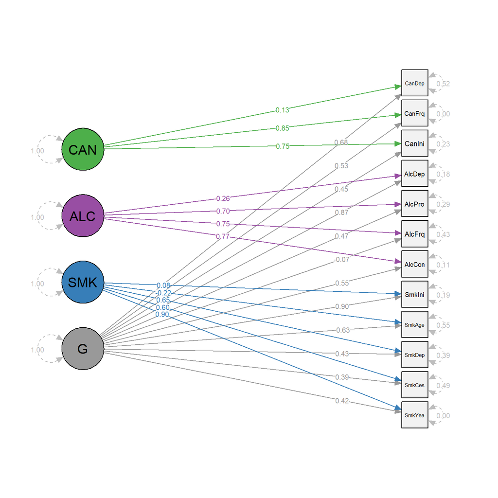

```r
semPaths(semPlotModel_GSEM(fit),
         layout="tree",
         curve = 2.5,
         whatLabels = "est",
         residuals = T,
         nodeLabels = nodelab,
         edge.color = edge.col,
         color = list(lat = c("grey60", "#377EB8", "#984EA3", "#4DAF4A"),
              man = "#f2f2f2"),
         rotation = 2,
         edge.label.position = c(rep(0.8, 12), rep(0.2, 5), rep(0.4, 4), rep(0.6, 3), rep(0.5, 28))
         )
```

### 23. Per stage - Bifactor uncorrelated

We fit the per stage bifactor model while removing the correlation between the factors. The fit decreases in respect to the correlated bifactor.

```r
bif <- 'G =~ NA*SMKINI + SMKAGE + CANEV + PACKYE + ALCCON + ALCFRQ + ALCP + CANFL + SMKDEP + ALCDEP + CANDEP + COCDEP + OPIODEP

INI =~ NA*SMKINI + SMKAGE + CANEV
FRQ =~ NA*PACKYE + ALCCON + ALCFRQ + ALCP + CANFL
DEP =~ NA*SMKDEP + ALCDEP + CANDEP + COCDEP + OPIODEP

G ~~ 0*INI + 0*FRQ + 0*DEP
INI ~~ 0*FRQ + 0*DEP
FRQ ~~ 0*DEP

G~~1*G
INI~~1*INI
FRQ~~1*FRQ
DEP~~1*DEP
'

#run the model
fit <- usermodel(ldscOut, estimation = "DWLS", model = bif, CFIcalc = TRUE)
```

```r
fitlabel <- paste0("CFI = ", round(fit$modelfit$CFI,3), ", SRMR = ", round(fit$modelfit$SRMR,3), ", AIC = ", round(fit$modelfit$AIC), ", Chisq = ", round(fit$modelfit$chisq))
kable(fitlabel)
```

| x |
| --- |
| CFI = 0.901, SRMR = 0.14, AIC = 1124, Chisq = 1046 |

**Click to expand table with model parameters**

```r
kable(fit$results)
```

|  | lhs | op | rhs | Unstand_Est | Unstand_SE | STD_Genotype | STD_Genotype_SE | STD_All | p_value |
| --- | --- | --- | --- | --- | --- | --- | --- | --- | --- |
| 38 | G | =~ | SMKINI | 0.2425896 | 0.00827862914018524 | 0.6990575 | 0.0243498889433765 | 0.6910958 | 0.0000000 |
| 36 | G | =~ | SMKAGE | -0.1219159 | 0.00692710674724437 | -0.5562154 | 0.031715919781976 | -0.5562154 | 0.0000000 |
| 31 | G | =~ | CANEV | 0.2210721 | 0.0211077843406107 | 0.3823385 | 0.0366849132034095 | 0.3823384 | 0.0000000 |
| 35 | G | =~ | PACKYE | 0.2006943 | 0.0101515351466016 | 0.6653740 | 0.0335556171605905 | 0.6653740 | 0.0000000 |
| 26 | G | =~ | ALCCON | 0.1721227 | 0.00718859097183067 | 0.6538715 | 0.0273072084462587 | 0.6538716 | 0.0000000 |
| 28 | G | =~ | ALCFRQ | -0.0065990 | 0.00685242125127211 | -0.0238864 | 0.023806313462645 | -0.0238864 | 0.3355425 |
| 29 | G | =~ | ALCP | 0.1322595 | 0.00829831585380672 | 0.5489945 | 0.0345631794107916 | 0.5489945 | 0.0000000 |
| 32 | G | =~ | CANFL | 0.1189671 | 0.0177519313338062 | 0.5606178 | 0.0839280417371903 | 0.5606180 | 0.0000000 |
| 37 | G | =~ | SMKDEP | 0.2091695 | 0.0175023435040938 | 0.6029000 | 0.0481725261453574 | 0.6028999 | 0.0000000 |
| 27 | G | =~ | ALCDEP | 0.3572586 | 0.0196206352284735 | 0.9555714 | 0.0516265768192324 | 0.9494470 | 0.0000000 |
| 30 | G | =~ | CANDEP | 0.2112326 | 0.0233492011457774 | 0.7032507 | 0.0775070593492063 | 0.7032570 | 0.0000000 |
| 33 | G | =~ | COCDEP | 0.3887882 | 0.03273661955534 | 0.7294776 | 0.0583760136144519 | 0.7294795 | 0.0000000 |
| 34 | G | =~ | OPIODEP | 0.3443167 | 0.0396860449523388 | 0.7869477 | 0.0906385390095726 | 0.7704969 | 0.0000000 |
| 44 | INI | =~ | SMKINI | 0.2503669 | 0.0387617827405672 | 0.7310214 | 0.110890023624708 | 0.7226956 | 0.0000000 |
| 43 | INI | =~ | SMKAGE | -0.0684879 | 0.0127246454925851 | -0.3162522 | 0.057587360134346 | -0.3162522 | 0.0000001 |
| 42 | INI | =~ | CANEV | 0.1865291 | 0.0369778452613287 | 0.3279998 | 0.0638912206572746 | 0.3279998 | 0.0000005 |
| 21 | FRQ | =~ | PACKYE | 0.1093400 | 0.0113592274959942 | 0.3615465 | 0.0376211983195024 | 0.3615464 | 0.0000000 |
| 17 | FRQ | =~ | ALCCON | -0.1483017 | 0.00898762375894663 | -0.5650123 | 0.0341927353491147 | -0.5650123 | 0.0000000 |
| 18 | FRQ | =~ | ALCFRQ | -0.2819153 | 0.01353217925356 | -0.9795077 | 0.0469376578284623 | -0.9795077 | 0.0000000 |
| 19 | FRQ | =~ | ALCP | -0.1349853 | 0.00964969938594214 | -0.5623893 | 0.0401443110688161 | -0.5623893 | 0.0000000 |
| 20 | FRQ | =~ | CANFL | -0.0359059 | 0.0168473646371155 | -0.1707124 | 0.079702567021169 | -0.1707125 | 0.0330685 |
| 14 | DEP | =~ | SMKDEP | 0.0504627 | 0.108524220170416 | 0.0860866 | 0.190820786918124 | 0.0860866 | 0.6419385 |
| 10 | DEP | =~ | ALCDEP | 0.0085766 | 0.0700047436550053 | -0.3157936 | 0.28539121433344 | -0.3137697 | 0.9024916 |
| 11 | DEP | =~ | CANDEP | 0.0150713 | 0.0747901736088495 | 0.3610507 | 0.307722449782495 | 0.3610539 | 0.8402967 |
| 12 | DEP | =~ | COCDEP | 0.3852513 | 0.79447718296938 | 0.1521870 | 0.217839638120614 | 0.1521874 | 0.6277389 |
| 13 | DEP | =~ | OPIODEP | 0.1393417 | 0.2863122918282 | 0.6509769 | 0.523255776108016 | 0.6373685 | 0.6264870 |
| 49 | SMKINI | ~~ | SMKINI | 0.0000996 | 0.0195829461541748 | 0.0000999 | 0.163893552937051 | 0.0000999 | 0.9959432 |
| 46 | PACKYE | ~~ | PACKYE | 0.0387662 | 0.0056621580881616 | 0.4265617 | 0.0620956567262284 | 0.4265617 | 0.0000000 |
| 47 | SMKAGE | ~~ | SMKAGE | 0.0282115 | 0.0026717100000708 | 0.5906090 | 0.0558655176630429 | 0.5906089 | 0.0000000 |
| 48 | SMKDEP | ~~ | SMKDEP | 0.0775591 | 0.0194833714373915 | 0.6291009 | 0.143132728030768 | 0.6291008 | 0.0000687 |
| 1 | ALCCON | ~~ | ALCCON | 0.0175061 | 0.00273782603676987 | 0.2532131 | 0.0395291843922162 | 0.2532131 | 0.0000000 |
| 3 | ALCFRQ | ~~ | ALCFRQ | 0.0032550 | 0.0067492492989241 | 0.0399942 | 0.0813366449992231 | 0.0399942 | 0.6296098 |
| 4 | ALCP | ~~ | ALCP | 0.0220512 | 0.00337250424988628 | 0.3823233 | 0.0583655919850643 | 0.3823233 | 0.0000000 |
| 2 | ALCDEP | ~~ | ALCDEP | 0.0170431 | 0.0256216905929069 | 0.0001003 | 0.277859983436577 | 0.0001003 | 0.5059350 |
| 6 | CANEV | ~~ | CANEV | 0.2456532 | 0.022387899494466 | 0.7462335 | 0.0679894439780858 | 0.7462335 | 0.0000000 |
| 5 | CANDEP | ~~ | CANDEP | 0.0449410 | 0.0285017335460151 | 0.3750629 | 0.397832089945859 | 0.3750697 | 0.1148455 |
| 7 | CANFL | ~~ | CANFL | 0.0292623 | 0.0155204747911662 | 0.6565642 | 0.347099165185797 | 0.6565647 | 0.0593763 |
| 8 | COCDEP | ~~ | COCDEP | 0.0001000 | 0.613850723875173 | 0.4446964 | 0.191320585356791 | 0.4446987 | 0.9998700 |
| 45 | OPIODEP | ~~ | OPIODEP | 0.0617258 | 0.102058154642723 | 0.0001001 | 0.7810451968856 | 0.0001001 | 0.5453051 |
| 25 | G | ~~ | INI | 0.0000000 |  | 0.0000000 |  | 0.0000000 | NA |
| 23 | G | ~~ | FRQ | 0.0000000 |  | 0.0000000 |  | 0.0000000 | NA |
| 22 | G | ~~ | DEP | 0.0000000 |  | 0.0000000 |  | 0.0000000 | NA |
| 40 | INI | ~~ | FRQ | 0.0000000 |  | 0.0000000 |  | 0.0000000 | NA |
| 39 | INI | ~~ | DEP | 0.0000000 |  | 0.0000000 |  | 0.0000000 | NA |
| 15 | FRQ | ~~ | DEP | 0.0000000 |  | 0.0000000 |  | 0.0000000 | NA |
| 24 | G | ~~ | G | 1.0000000 |  | 1.0000000 |  | 1.0000000 | NA |
| 41 | INI | ~~ | INI | 1.0000000 |  | 1.0000000 |  | 1.0000000 | NA |
| 16 | FRQ | ~~ | FRQ | 1.0000000 |  | 1.0000000 |  | 1.0000000 | NA |
| 9 | DEP | ~~ | DEP | 1.0000000 |  | 1.0000000 |  | 1.0000000 | NA |

```r
fwrite(fit$results, "results/modeloutput/pertrait_bifactor_uncor.csv")
```

#### Plot Per stage - Bifactor uncorrelated

```r
nodelab <- c("SmkIni", "SmkAge", "CanIni",
             "SmkYea", "AlcCon", "AlcFrq", "AlcPro", "CanFrq",
             "SmkDep", "AlcDep", "CanDep", "CocDep", "OpioDep",
             "G", "INI", "FRQ", "DEP")

edge.col <- c(rep("grey60", 13),
              rep("#FF7F00", 3),
              rep("#17BECF", 5),
              rep("#D62728", 5),
              rep("grey", 13),
              rep("white", 6),
              rep("grey", 4))


svg("results/semplot_per-type_bifactor_orthogonal.svg", width = 8, height = 8)

semPaths(semPlotModel_GSEM(fit),
         layout="tree",
         curve = 2.5,
         whatLabels = "est",
         residuals = T,
         nodeLabels = nodelab,
         edge.color = edge.col,
         color = list(lat = c("grey60", "#FF7F00", "#17BECF", "#D62728"),
              man = "#f2f2f2"),
         rotation = 2,
         edge.label.position = c(rep(0.8, 13), rep(0.4, 3), rep(0.4, 5), rep(0.4, 5), rep(0.5, 29))
         )

dev.off()
```

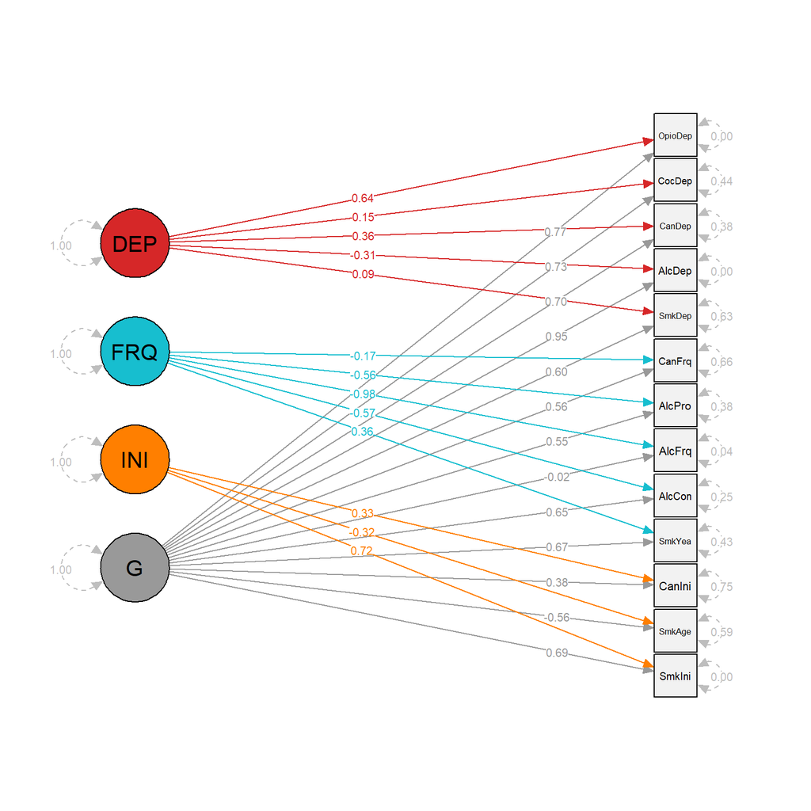

```r
semPaths(semPlotModel_GSEM(fit),
         layout="tree",
         curve = 2.5,
         whatLabels = "est",
         residuals = T,
         nodeLabels = nodelab,
         edge.color = edge.col,
         color = list(lat = c("grey60", "#FF7F00", "#17BECF", "#D62728"),
              man = "#f2f2f2"),
         rotation = 2,
         edge.label.position = c(rep(0.8, 13), rep(0.4, 3), rep(0.4, 5), rep(0.4, 5), rep(0.5, 29))
         )
```